# Machine Learning: Mathematical Theory and Applications

Computer lab 3

Thu Trang Tran - 26038024

Published

October 24, 2025

**Warning**

The instructions in this lab assume that the following package is installed:

- `caret`

Packages may be installed by executing `install.packages('packagename')`, where `'packagename'` is the name of the package, e.g. `'splines'`. You may have to install additional packages to solve the computer lab. If you want this file to run locally on your computer, you have to change some paths to where the data are stored (see below).

## Introduction

This computer lab corresponds to Module 4 and treats topics such as supervised learning, unsupervised learning, and semi-supervised learning.

**Instructions**

In this computer lab, you will work individually but you are free to discuss with other students, especially the one student you worked with on Computer lab 2! However, you have to hand in your own set of solutions. **It is strictly forbidden to copy anyone else’s code or solutions**. This is regarded as academic misconduct and may have serious consequences for you. **Irresponsible use of AI tools (such as ChatGPT) is not recommended**. Keep in mind that such tools are not permitted in the invigilated final project.

This computer lab is worth a total of 15 marks (the subject has a maximum of 100 marks). The maximum marks for a given problem is shown within parenthesis at the top of the section. The marking rubric is available on Canvas. The problems you should solve are marked with the symbol 💪 and surrounded by a box. Hand in the solutions and programming codes in any form you like, however, I will not be accepting any obscure .docx or .xlsx files (convert to pdf if needed). You are encouraged to learn how to use Quarto to generate scientific and technical reports. (This computer lab is typeset in Quarto.) A Quarto template on Canvas is provided for this purpose. If you use Quarto, hand in the report in the form of a html document generated by Quarto. **Before submitting, carefully check that the document compiles without any errors**. Use properly formatted figures and programming code.

**Warning**

Submitting poorly written reports may result in loss of marks. The same applies to poorly formatted reports (including poorly formatted code/figures, unnecessarily long outputs, etc.).

## 1. Linear discriminant analysis for cancer data (2 marks)

In this problem, we consider a generative classification model for breast cancer data, where features computed from 569 digitised images are modelled and subsequently used to classify the tumor type (malign or benign). The data is stored in the file `cancer_data_10features.Rdata`, which can be downloaded from the Canvas page of the course[^1].

We will consider the two features `radius` (mean of distances from center to points on the perimeter ) and `texture` (standard deviation of gray-scale values). Your task in this problem is to implement a linear discriminant analysis method without using packages (such as the `lda()` function from the `MASS` package).

The following code reads in the data, creates the training and test datasets, and visualises these data for the classification problem.

```r
suppressMessages(library(glue))
suppressMessages(library(mixtools))
suppressMessages(library(pROC))
```

```r
rm(list=ls()) # Remove variables
cat("\014") # Clean workspace
```

```r
set.seed(1234)
suppressMessages(library(caret))
load("C:/Users/26038024/Downloads/cancer_data_10features.RData")
train_obs <- createDataPartition(y = cancer_data_10features$diagnosis, p = .80, list = FALSE)
train <- cancer_data_10features[train_obs, 1:3]
test <- cancer_data_10features[-train_obs, 1:3]
# Confirm both training and test are balanced with respect to diagnosis (malign tumor)
cat("Percentage of training data consisting of malign tumors:",
              100*mean(train$diagnosis == "M"))
```

```
Percentage of training data consisting of malign tumors: 37.2807
```

```r
cat("Percentage of test data consisting of malign tumors:",
              100*mean(test$diagnosis == "M"))
```

```
Percentage of test data consisting of malign tumors: 37.16814
```

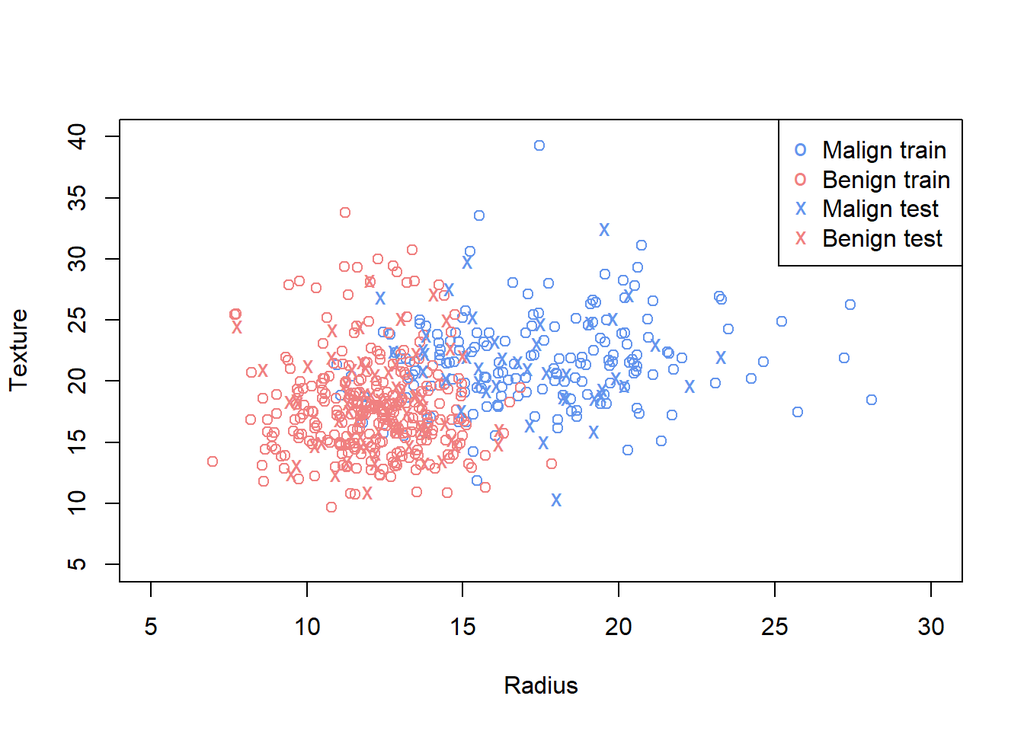

```r
# Train and test for each tumor class
ind_train_M <- train$diagnosis == "M"
ind_test_M <- test$diagnosis == "M"
plot(train[ind_train_M, 2], train[ind_train_M, 3], xlab = "Radius", ylab = "Texture", col = "cornflowerblue", xlim = c(5, 30),  ylim = c(5, 40))
lines(train[!ind_train_M, 2], train[!ind_train_M, 3], col = "lightcoral", type = "p")
lines(test[ind_test_M, 2], test[ind_test_M, 3], col = "cornflowerblue", type = "p", pch = "x")
lines(test[!ind_test_M, 2], test[!ind_test_M, 3], col = "lightcoral", type = "p", pch = "x")
legend("topright", legend = c("Malign train", "Benign train", "Malign test", "Benign test"), col = c("cornflowerblue", "lightcoral", "cornflowerblue", "lightcoral"), pch = c("o", "o", "x", "x"))
```

Assume that the class conditionals $p(\mathbf{x}|y)$, for $y\in\{1, 2\}$ (1-malign, 2-benign), follow a bivariate normal distribution with different means, however, with the same covariance matrix, i.e.
$$\mathbf{x}|y=m \sim \mathcal{N}(\boldsymbol{\mu}_m,\boldsymbol{\Sigma}),\,\,m=1,2.$$

Let $\pi_m=\Pr(y=m)$ for $m=1,2$. These $\pi_m$ probabilities can be interpreted as the marginal (marginalising out $\mathbf{x}$ through $\Pr(y=m)=\int p(\mathbf{x}, y=m)\mathbf{d}\mathbf{x}$) class membership probabilities, i.e. unconditional $\mathbf{x}$. Given an $\mathbf{x}=(x_1, x_2)^\top$, we want to compute its class membership probability. From Bayes’ theorem, it follows that the conditional distribution of the class membership is
$$\Pr(y=m|\mathbf{x})=\frac{p(\mathbf{x}|y=m)\Pr(y=m)}{p(\mathbf{x})}\propto p(\mathbf{x}|y=m)\Pr(y=m),\,\,m=1,2.$$

The denominator above is the marginal density of $\mathbf{x}$ (marginalizing out $y$ through $p(\mathbf{x})=\sum_m p(\mathbf{x}, y=m)$), which normalizes $\Pr(y=m|\mathbf{x})$ so that $\sum_m\Pr(y=m|\mathbf{x})=1$.

#### 💪 Problem 1.1

Derive (analytically) $p(\mathbf{x})$ for the example above.

**Note**

**Answers:**

We have $p(\mathbf{x})=\sum_{m=1}^{M} p(\mathbf{x}, y=m) = \sum_{m=1}^{M} p(\mathbf {x}|y=m) . p(y=m)$

with $\mathbf{x}|y=m \sim \mathcal{N}(\boldsymbol{\mu}_m,\boldsymbol{\Sigma}), m=1,2$ and d=2 (number of classes), we can write

$p(\mathbf{x}| y=m) = \frac{1}{(2\pi)^{(d=2)/2} |\Sigma|^{1/2}} \exp\left( -\frac{1}{2} (x - \mu_m)^\top \Sigma^{-1} (x - \mu_m) \right)$

Let $p(y=1) = \pi_1$ and $p(y=2) = \pi_2$

So

$\begin{align*} p(\mathbf{x}) & = \pi_1 \times \frac{1}{(2\pi) |\Sigma|^{1/2}} \exp\left( -\frac{1}{2} (\mathbf{x} - \mu_1)^\top \Sigma^{-1} (\mathbf{x} - \mu_1) \right)\\ &\quad + \pi_2 \times \frac{1}{(2\pi) |\Sigma|^{1/2}} \exp\left( -\frac{1}{2} (\mathbf{x} - \mu_2)^\top \Sigma^{-1} (\mathbf{x} - \mu_2) \right) \end{align*}$

#### 💪 Problem 1.2

Given the training data, estimate the parameters $\pi_m,\boldsymbol{\mu}_m$ for $m=1,2$, and $\boldsymbol{\Sigma}$. Predict the labels of the test data and plot them in a scatter plot with different colors to represent the different classes.

**Tip**

Let $\mathbf{x}_\star=(x_{\star1}, x_{\star2})^\top$ be a point we want to predict $y$ for and let $\widehat{y}(\mathbf{x}_\star)$ denote the prediction. The prediction is obtained as
$$\widehat{y}(\mathbf{x}_\star)= \arg \max_m \Pr(y=m|\mathbf{x})=\arg \max_m \log \Pr(y=m|\mathbf{x}).$$
It can be shown that for the model above,
$$\widehat{y}(\mathbf{x}_\star)=\arg\max_m \left\{ \log p(\mathbf{x}_\star|y=m) + \log\pi_m \right\}=\arg\max_m \left\{ \mathbf{x}_{\star}^{\top}\boldsymbol{\Sigma}^{-1}\boldsymbol{\mu}_{m} - \frac{1}{2}\boldsymbol{\mu}_{m}^{\top}\boldsymbol{\Sigma}^{-1}\boldsymbol{\mu}_{m}+\log \pi_{m}\right\}.$$

```r
# pi is the probability that a random observation is in class M or B
pi_m_train = mean(train$diagnosis == "M")
pi_b_train = 1-pi_m_train
```

```r
# mu is the mean of each class
mean_m_radius_train = mean(train[ind_train_M, 2])
mean_m_texture_train = mean(train[ind_train_M, 3])
mu_m_train = c(mean_m_radius_train, mean_m_texture_train)

mean_b_radius_train = mean(train[!ind_train_M, 2])
mean_b_texture_train = mean(train[!ind_train_M, 3])
mu_b_train = c(mean_b_radius_train, mean_b_texture_train)

mu_matrix_train = cbind(M = mu_m_train, B = mu_b_train)
rownames(mu_matrix_train) <- c("radius", "texture")
```

With LDA, the common covariance matrix is estimated using all data:

$\hat{\Sigma} = \frac{1}{n} \sum_{m=1}^{M} \sum_{i : y_i = m} (x_i - \hat{\mu}_m)(x_i - \hat{\mu}_m)^\top$

```r
common_cov_matrix = function(variable, mu_matrix){
  class_scatter <- matrix(0, nrow = 2, ncol = 2)
  for (k in c("M", "B")){
    variable_k <- as.matrix(variable[variable$diagnosis == k, 2:3])

    # Get the mean vector for class k
    mu_k <- mu_matrix[, k]

    for (i in (1: (nrow(variable_k)))){
      class_scatter = class_scatter + (variable_k[i, ] - mu_k)%*%t(variable_k[i, ]- mu_k)}
    }
  return (1/(nrow(variable)-2)*class_scatter)}
```

```r
common_cov = common_cov_matrix(variable = train, mu_matrix = mu_matrix_train)
print(common_cov)
```

```
       radius   texture
[1,] 6.204664  0.552331
[2,] 0.552331 15.645241
```

**Classify using discriminant function**

We need to choose the class that maximizes the posterior probability $P(y=m|x) = p(\mathbf{x}|y=m)\Pr(y=m)$

From problem 1.1, we have $p(\mathbf{x}| y=m) = \frac{1}{2\pi |\Sigma|^{1/2}} \exp\left( -\frac{1}{2} (x - \mu_m)^\top \Sigma^{-1} (x - \mu_m) \right)$

So $\log(p(\mathbf{x}| y=m)) = \log\left(\frac{1}{2\pi |\Sigma|^{1/2}} \exp\left( -\frac{1}{2} (x - \mu_m)^\top \Sigma^{-1} (x - \mu_m) \right)\right)$

$= \log \left(\frac{1}{2\pi |\Sigma|^{1/2}}\right) + \log \left( \exp\left( -\frac{1}{2} (x - \mu_m)^\top \Sigma^{-1} (x - \mu_m) \right)\right)$

$= -\log 2\pi - \log |\Sigma|^{1/2} - \frac{1}{2} (x - \mu_m)^\top \Sigma^{-1} (x - \mu_m)$

$\propto - \frac{1}{2} (x - \mu_m)^\top \Sigma^{-1} (x - \mu_m)$ (we drop $-\log 2\pi - \log |\Sigma|^{1/2}$ as they don’t depend on m)

and $\log \Pr(y=m) = \log \pi_m$

so we need to choose m that maximizes the function:

$\log P(y=m|x) \propto - \frac{1}{2} (x - \mu_m)^\top \Sigma^{-1} (x - \mu_m) + \log \pi_m$

```r
# Prediction with discriminant function
predictions_LDA <- character(nrow(test))

for (i in (1:nrow(test))){
  x_i = t(as.matrix(test[i, 2:3]))
  posterior_i_m = -0.5*t(x_i - mu_m_train)%*%solve(common_cov)%*%(x_i - mu_m_train) +log(pi_m_train)
  posterior_i_b = -0.5*t(x_i - mu_b_train)%*%solve(common_cov)%*%(x_i - mu_b_train) +log(pi_b_train)
  if (posterior_i_m >= posterior_i_b){
    predictions_LDA[i] <- "M"
  } else {
    predictions_LDA[i] <- "B"
  }
}
test$prediction_LDA <- factor(predictions_LDA, levels = levels(test$diagnosis))
```

```r
confusionMatrix(data = test$prediction_LDA, test$diagnosis, positive = "M")
```

```
Confusion Matrix and Statistics

          Reference
Prediction  B  M
         B 68  8
         M  3 34

               Accuracy : 0.9027
                 95% CI : (0.8325, 0.9504)
    No Information Rate : 0.6283
    P-Value [Acc > NIR] : 3.429e-11

                  Kappa : 0.7864

 Mcnemar's Test P-Value : 0.2278

            Sensitivity : 0.8095
            Specificity : 0.9577
         Pos Pred Value : 0.9189
         Neg Pred Value : 0.8947
             Prevalence : 0.3717
         Detection Rate : 0.3009
   Detection Prevalence : 0.3274
      Balanced Accuracy : 0.8836

       'Positive' Class : M
```

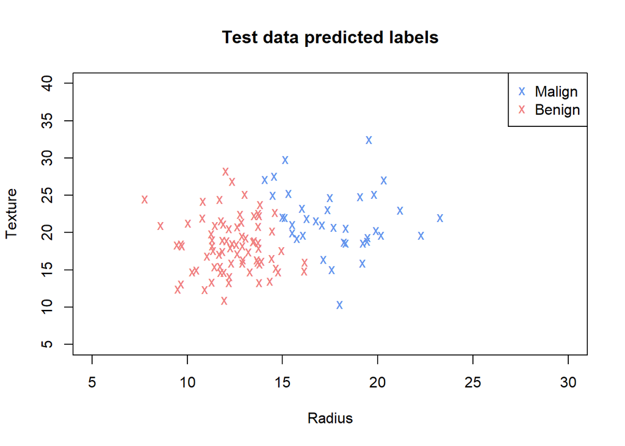

```r
# Logical indices for predictions
pred_m_ind <- test$prediction_LDA == "M"
pred_b_ind <- test$prediction_LDA == "B"

plot(test$radius[pred_m_ind], test$texture[pred_m_ind],
     xlab = "Radius", ylab = "Texture",
     col = "cornflowerblue", pch = 'x',
     xlim = c(5, 30), ylim = c(5, 40),
     main = "Test data predicted labels")

points(test$radius[pred_b_ind], test$texture[pred_b_ind],
       col = "lightcoral", pch = 'x')

legend("topright", legend = c("Malign", "Benign"),
       col = c("cornflowerblue", "lightcoral"), pch = c('x', 'x'))
```

#### 💪 Problem 1.3

Plot the decision bound of the classifier and the predictions of the test data from Problem 1.2 in the same plot.

**Tip**

To determine the decision boundary, we can solve the equation $\log\Pr(y=1|\mathbf{x}_\star)=\log\Pr(y=2|\mathbf{x}_\star)$ for $\mathbf{x}_\star=(x_{\star1}, x_{\star2})^\top$. This gives
$$\mathbf{x}_{\star}^{\top}\boldsymbol{\Sigma}^{-1}(\boldsymbol{\mu}_{1} - \boldsymbol{\mu}_{2})- \frac{1}{2}\boldsymbol{\mu}_{1}^{\top}\boldsymbol{\Sigma}^{-1}\boldsymbol{\mu}_{1} + \frac{1}{2}\boldsymbol{\mu}_{2}^{\top}\boldsymbol{\Sigma}^{-1}\boldsymbol{\mu}_{2}+\log \pi_{1} - \log \pi_{2}=0.$$

After some algebra, we can express the above as $x_{\star2}=\gamma_0 + \gamma_1x_{\star1}$ for some $\gamma_0,\gamma_1$ that can be evaluated using the estimated $\pi_m,\boldsymbol{\mu}_m$, and $\boldsymbol{\Sigma}$. We can now construct a grid for $x_{\star1}$ (e.g. `x1_grid<-seq(5,30,length.out = 100)`) and use $x_{\star2}=\gamma_0 + \gamma_1x_{\star1}$ to plot the decision bound.

**Decision boundary**

The decision boundary is the line where $\log \Pr(y=1|x_{*}) = \log \Pr(y=2|x_{*})$

$\Leftrightarrow - \frac{1}{2} (x_* - \mu_1)^\top \Sigma^{-1} (x_* - \mu_1) + \log \pi_1 = - \frac{1}{2} (x_* - \mu_2)^\top \Sigma^{-1} (x_* - \mu_2) + \log \pi_2$

$\Leftrightarrow - \frac{1}{2} \left(x_*^{\top} \Sigma^{-1} x_*- 2 \mu_1^{\top} \Sigma^{-1} x_*+ \mu_1^{\top} \Sigma^{-1} \mu_1 \right) + \log \pi_1 = - \frac{1}{2} \left (x_*^{\top} \Sigma^{-1} x_*- 2 \mu_2^{\top} \Sigma^{-1} x_*+ \mu_2^{\top} \Sigma^{-1} \mu_2 \right ) + \log \pi_2$

$\Leftrightarrow \mu_1^{\top} \Sigma^{-1} x_* - \frac{1}{2} \mu_1^{\top} \Sigma^{-1} \mu_1 + \log \pi_1 = \mu_2^{\top} \Sigma^{-1} x_* - \frac{1}{2}\mu_2^{\top} \Sigma^{-1} \mu_2 + \log \pi_2$

$\Leftrightarrow (\mu_1^{\top} - \mu_2^{\top} ) \Sigma^{-1} x_* - \frac{1}{2}( \mu_1^{\top} \Sigma^{-1} \mu_1 - \mu_2^{\top} \Sigma^{-1} \mu_2) + \log \pi_1 - \log \pi_2 = 0$

$\Leftrightarrow x_*^\top \Sigma^{-1} (\mu_1- \mu_2) - \frac{1}{2}( \mu_1^{\top} \Sigma^{-1} \mu_1 - \mu_2^{\top} \Sigma^{-1} \mu_2) + \log \pi_1 - \log \pi_2 = 0$ $(1)$

Let $w$ denote the projection direction, we have $w = \Sigma^{-1} (\mu_1- \mu_2)$

$w[1]$ and $w[2]$ are the first and second entry of $w$ respectively.

With $\mathbf{x}_\star=(x_{\star1}, x_{\star2})^\top$, we can write $(1)$ as below:

$x_{*1} w[1] +x_{*2} w[2] - \frac{1}{2}( \mu_1^{\top} \Sigma^{-1} \mu_1 - \mu_2^{\top} \Sigma^{-1} \mu_2) + \log \pi_1 - \log \pi_2 = 0$

$\Leftrightarrow x_{*2} = \frac {\frac{1}{2}( \mu_1^{\top} \Sigma^{-1} \mu_1 - \mu_2^{\top} \Sigma^{-1} \mu_2) - \log \pi_1 + \log \pi_2}{w[2]} - x_{*1}\frac {w[1]}{w[2]}$

So $\gamma_0 = \frac {\frac{1}{2}( \mu_1^{\top} \Sigma^{-1} \mu_1 - \mu_2^{\top} \Sigma^{-1} \mu_2) - \log \pi_1 + \log \pi_2}{w[2]}$

and $\gamma_1 = - \frac {w[1]}{w[2]}$

```r
w= solve(common_cov)%*%(mu_m_train - mu_b_train)
print(w)
```

```
             [,1]
radius  0.8559520
texture 0.2103473
```

```r
gamma_0 = as.numeric((0.5*(t(mu_m_train)%*%solve(common_cov)%*%mu_m_train - t(mu_b_train)%*%solve(common_cov)%*%mu_b_train) - log(pi_m_train)+ log(pi_b_train))/w[2])
gamma_1 = as.numeric(-w[1]/w[2])

x1_grid<-seq(5,30,length.out = 100)
x2_grid = gamma_0 + gamma_1*x1_grid
```

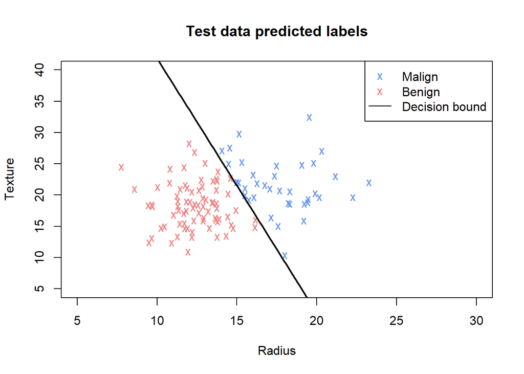

```r
plot(test$radius[pred_m_ind], test$texture[pred_m_ind],
     xlab = "Radius", ylab = "Texture",
     col = "cornflowerblue", pch = 'x',
     xlim = c(5, 30), ylim = c(5, 40),
     main = "Test data predicted labels")

points(test$radius[pred_b_ind], test$texture[pred_b_ind],
       col = "lightcoral", pch = 'x')

lines(x1_grid, x2_grid, col = 'black', lwd = 2)

legend("topright", legend = c("Malign", "Benign", "Decision bound"),
       col = c("cornflowerblue", "lightcoral", 'black'), lty = c(NA,NA,1), pch = c('x', 'x',NA))
```

#### 💪 Problem 1.4

Fit a logistic regression to the training data using the `glm()` function. Compare the results to the generative model in Problem 1.2. Comment on the results.

**Tip**

By now you should know many metrics to evaluate a binary classifier.

```r
test <- test[, -c(4, 5)]
glm_fit <- glm(train$diagnosis ~ ., family = binomial, data = train)
y_prob_glm_test <- predict(glm_fit, newdata = test, type = "response")

threshold <- 0.5
y_glm_test <- as.factor(y_prob_glm_test > threshold)
levels(y_glm_test) <- c("B", "M")
confusionMatrix(data = y_glm_test, test$diagnosis, positive = "M")
```

```
Confusion Matrix and Statistics

          Reference
Prediction  B  M
         B 65  8
         M  6 34

               Accuracy : 0.8761
                 95% CI : (0.8009, 0.9306)
    No Information Rate : 0.6283
    P-Value [Acc > NIR] : 3.585e-09

                  Kappa : 0.7321

 Mcnemar's Test P-Value : 0.7893

            Sensitivity : 0.8095
            Specificity : 0.9155
         Pos Pred Value : 0.8500
         Neg Pred Value : 0.8904
             Prevalence : 0.3717
         Detection Rate : 0.3009
   Detection Prevalence : 0.3540
      Balanced Accuracy : 0.8625

       'Positive' Class : M
```

**Note**

**Answers:**

When comparing the confusion matrices at the same decision threshold of $0.5$, LDA consistently outperforms logistic regression across most key metrics by a margin of less than 6%. Given that this is a medical dataset, accuracy and sensitivity are the most critical metrics. LDA achieves an accuracy of 90% compared to 87% for logistic regression, while both models share the same sensitivity, correctly identifying 80% of malignant cases.

The difference likely arises from the models’ underlying approaches: LDA is a generative model, which learns how data for each class are distributed by estimating parameters $\Sigma, \pi, \mu$ and computing $P(y|\mathbf{x}) = \frac{P(\mathbf{x}|y)P(y)}{P(\mathbf{x})}$ , thereby incorporating the structure of the feature.

Logistic regression, in contrast, is a discriminative model that estimates parameters $(\beta_0, \beta_1)$ via maximum likelihood, $L(\boldsymbol{\beta}) = \prod_i P(y_i | \mathbf{x}_i)$ , focusing on the decision boundary.

Consequently, when LDA’s assumptions (near normality and equal covariance matrices) hold, it tends to produce lower variance and slightly better performance than the logistic model.

## 2. Quadratic discriminant analysis for cancer data (3 marks)

A more flexible model allows a different covariance matrix for each class conditional, i.e.
$$\mathbf{x}|y=m \sim \mathcal{N}(\boldsymbol{\mu}_m,\boldsymbol{\Sigma}_m).$$
It can be shown that
$$\widehat{y}(\mathbf{x}_{\star})=\arg\underset{m}{\max}\left(-\frac{1}{2}\log\left|\boldsymbol{\Sigma}_{m}\right|-\frac{1}{2}(\mathbf{x}_{\star}-\boldsymbol{\mu}_{m})^{\top}\boldsymbol{\Sigma}_{m}^{-1}(\mathbf{x}_{\star}-\boldsymbol{\mu}_{m})+\log\pi_{m}\right),$$

where $\left|\cdot\right|$ denotes the determinant. We note that $\mathbf{x}_\star$ is quadratic in the expression of the $\log\Pr(y=m|\mathbf{x}_\star)$, and hence the decision boundary is not linear for this classifier.

#### 💪 Problem 2.1

Derive (analytically) $p(\mathbf{x})$ with the new class conditional distribution above.

**Note**

**Answers:**

We have $p(\mathbf{x})=\sum_{m=1}^{M} p(\mathbf{x}, y=m) = \sum_{m=1}^{M} p(\mathbf {x}|y=m) . p(y=m)$ $(1)$

with $\mathbf{x}|y=m \sim \mathcal{N}(\boldsymbol{\mu}_m,\boldsymbol{\Sigma_m}), m=1,2$ and d=2 (number of classes), we can write

$p(\mathbf{x}| y=m) = \frac{1}{(2\pi)^{(d=2)/2} |\Sigma_m|^{1/2}} \exp\left( -\frac{1}{2} (x - \mu_m)^\top \Sigma_{m}^{-1} (x - \mu_m) \right)$ $(2)$

and $p(y=m) = \pi_m$ $(3)$

Plug $(2)$ and $(3)$ into $(1)$, we have:

$p(\mathbf{x})= \sum_{m=1}^{M} \frac{1}{2\pi |\Sigma_m|^{1/2}} \exp\left( -\frac{1}{2} (x - \mu_m)^\top \Sigma_{m}^{-1} (x - \mu_m) \right) \times \pi_m$

$\Leftrightarrow p(\mathbf{x}) = \frac{1}{2\pi} \left( \frac{\pi_1}{|\Sigma_1|^{1/2}} \exp\left( -\frac{1}{2} (x - \mu_1)^\top \Sigma_{1}^{-1} (x - \mu_1) \right) + \frac{\pi_2}{|\Sigma_2|^{1/2}} \exp\left( -\frac{1}{2} (x - \mu_2)^\top \Sigma_{2}^{-1} (x - \mu_2) \right) \right)$

#### 💪 Problem 2.2

Given the training data, estimate the parameters $\pi_m,\boldsymbol{\mu}_m$, and $\boldsymbol{\Sigma}_m$ for $m=1,2$. Predict the labels of the test data and plot them in a scatter plot with different colors to represent the different classes.

**Tip**

The log of the determinant of a matrix $A$ can be computed as `log(det(A))`.

```r
# pi_m is the same as in Problem 1, printing them again
cat(glue('Pi malign in train data: {pi_m_train}\nPi benign in train data: {pi_b_train}'))
```

```
Pi malign in train data: 0.37280701754386
Pi benign in train data: 0.62719298245614
```

```r
# mu_m is the same as in Problem 1, printing them again
print(glue("Mu matrix:\n\n{paste(capture.output(print(mu_matrix_train)), collapse = '\n')}"))
```

```
Mu matrix:

               M        B
radius  17.53441 12.10734
texture 21.62594 17.86224
```

```r
# extract the malign observations in train data
train_m_obs <- as.matrix(train[train$diagnosis == 'M', 2:3])
cov_m = cov(train_m_obs)
# extract the benign observation in train data
train_b_obs <- as.matrix(train[train$diagnosis == 'B', 2:3])
cov_b =cov(train_b_obs)

cat(glue("Covariance matrix of malign observations in train data:\n{paste(capture.output(print(cov_m)), collapse = '\n')}\n\n\n"))
```

```
Covariance matrix of malign observations in train data:
           radius   texture
radius  11.153848  1.959863
texture  1.959863 13.998163
```

```r
cat(glue("Covariance matrix of benign observations in train data:\n{paste(capture.output(print(cov_b)), collapse = '\n')}\n"))
```

```
Covariance matrix of benign observations in train data:
            radius    texture
radius   3.2698848 -0.2823108
texture -0.2823108 16.6219297
```

We need to choose the class that maximizes the posterior probability $P(y=m|x) = p(\mathbf{x}|y=m)\Pr(y=m)$

From problem 2.1, we have $p(\mathbf{x}| y=m) = \frac{1}{2\pi |\Sigma_m|^{1/2}} \exp\left( -\frac{1}{2} (x - \mu_m)^\top \Sigma_m^{-1} (x - \mu_m) \right)$

So $\log(p(\mathbf{x}| y=m)) = \log\left(\frac{1}{2\pi |\Sigma_m|^{1/2}} \exp\left( -\frac{1}{2} (x - \mu_m)^\top \Sigma_m^{-1} (x - \mu_m) \right)\right)$

$= \log \left(\frac{1}{2\pi |\Sigma_m|^{1/2}}\right) + \log \left( \exp\left( -\frac{1}{2} (x - \mu_m)^\top \Sigma_m^{-1} (x - \mu_m) \right)\right)$

$= -\log 2\pi - \log |\Sigma_m|^{1/2} - \frac{1}{2} (x - \mu_m)^\top \Sigma_m^{-1} (x - \mu_m)$

$\propto - \frac {1}{2}\log |\Sigma_m| - \frac{1}{2} (x - \mu_m)^\top \Sigma_m^{-1} (x - \mu_m)$ (we drop $-\log 2\pi$ as it doesn’t depend on $m$)

and $\log \Pr(y=m) = \log \pi_m$

so we need to choose m that maximizes the function:

$\log P(y=m|x) \propto - \frac {1}{2}\log |\Sigma_m| - \frac{1}{2} (x - \mu_m)^\top \Sigma_m^{-1} (x - \mu_m) + \log \pi_m$

```r
predictions_QDA <- character(nrow(test))

for (i in (1:nrow(test))){
  x_i = as.numeric(test[i, 2:3])
  posterior_i_m = -0.5*log(det(cov_m))-0.5*t(x_i - mu_m_train)%*%solve(cov_m)%*%(x_i - mu_m_train) +log(pi_m_train)
  posterior_i_b = -0.5*log(det(cov_b))-0.5*t(x_i - mu_b_train)%*%solve(cov_b)%*%(x_i - mu_b_train) +log(pi_b_train)
  if (posterior_i_m >= posterior_i_b){
    predictions_QDA[i] <- "M"
  } else {
    predictions_QDA[i] <- "B"
  }
}
test$prediction_QDA <- factor(predictions_QDA, levels = levels(test$diagnosis))
```

```r
confusionMatrix(data = test$prediction_QDA, test$diagnosis, positive = "M")
```

```
Confusion Matrix and Statistics

          Reference
Prediction  B  M
         B 65  8
         M  6 34

               Accuracy : 0.8761
                 95% CI : (0.8009, 0.9306)
    No Information Rate : 0.6283
    P-Value [Acc > NIR] : 3.585e-09

                  Kappa : 0.7321

 Mcnemar's Test P-Value : 0.7893

            Sensitivity : 0.8095
            Specificity : 0.9155
         Pos Pred Value : 0.8500
         Neg Pred Value : 0.8904
             Prevalence : 0.3717
         Detection Rate : 0.3009
   Detection Prevalence : 0.3540
      Balanced Accuracy : 0.8625

       'Positive' Class : M
```

Similar to LDA, the decision boundary of QDA is the line where $\log \Pr(y=1|x_{*}) = \log \Pr(y=2|x_{*})$

$\Leftrightarrow -\frac {1}{2}\log |\Sigma_1| - \frac{1}{2} (x_* - \mu_1)^\top \Sigma_1^{-1} (x_* - \mu_1) + \log \pi_1 = -\frac {1}{2}\log |\Sigma_2| - \frac{1}{2} (x_* - \mu_2)^\top \Sigma_2^{-1} (x_* - \mu_2) + \log \pi_2$

$\begin{align*}\Leftrightarrow - \frac{1}{2} \left[ x_*^\top \Sigma_1^{-1} x_* - 2 \mu_1^\top \Sigma_1^{-1} x_* + \mu_1^\top \Sigma_1^{-1} \mu_1 \right] &+ \frac{1}{2} \left[ x_*^\top \Sigma_2^{-1} x_* - 2 \mu_2^\top \Sigma_2^{-1} x_* + \mu_2^\top \Sigma_2^{-1} \mu_2 \right] \\ &+ \log \pi_1 - \log \pi_2 - \frac{1}{2} \log |\Sigma_1| + \frac{1}{2} \log |\Sigma_2| = 0 \end{align*}$

$\begin{align*}\Leftrightarrow -\frac{1}{2} \Big[x_*^\top (\Sigma_1^{-1} - \Sigma_2^{-1}) x_* + 2 (-\mu_1^\top \Sigma_1^{-1} + \mu_2^\top \Sigma_2^{-1}) x_* & \quad + (\mu_1^\top \Sigma_1^{-1} \mu_1 - \mu_2^\top \Sigma_2^{-1} \mu_2) \Big] \\ & \quad + \log \pi_1 - \log \pi_2 - \frac{1}{2} \log |\Sigma_1| + \frac{1}{2} \log |\Sigma_2| = 0 \end{align*}$ $\begin{align*}\Leftrightarrow \ &x_*^\top \left( -\frac{1}{2}(\Sigma_1^{-1} - \Sigma_2^{-1}) \right) x_* + (\mu_1^\top \Sigma_1^{-1} - \mu_2^\top \Sigma_2^{-1}) x_* \\&+ \left[-\frac{1}{2} (\mu_1^\top \Sigma_1^{-1} \mu_1 - \mu_2^\top \Sigma_2^{-1} \mu_2)+ \log \pi_1 - \log \pi_2- \frac{1}{2} \log |\Sigma_1| + \frac{1}{2} \log |\Sigma_2|\right] = 0 \end{align*}$

The QDA boundary equation is: $x_*^\top A x_* + b^\top x_* + c = 0$

So $A = -\frac{1}{2}(\Sigma_1^{-1} - \Sigma_2^{-1})$

$b^\top = \mu_1^\top \Sigma_1^{-1} - \mu_2^\top \Sigma_2^{-1}$

$c =-\frac{1}{2} (\mu_1^\top \Sigma_1^{-1} \mu_1 - \mu_2^\top \Sigma_2^{-1} \mu_2)+ \log \pi_1 - \log \pi_2- \frac{1}{2} \log |\Sigma_1| + \frac{1}{2} \log |\Sigma_2|$

With

$$x_* =
\begin{bmatrix}
x_1 \\
x_2
\end{bmatrix}, \quad
A =
\begin{bmatrix}
a_{11} & a_{12} \\
a_{12} & a_{22}
\end{bmatrix}, \quad
b =
\begin{bmatrix}
b_1 \\
b_2
\end{bmatrix}$$

$$x_*^\top A x_* =
\begin{bmatrix}
x_1 & x_2
\end{bmatrix}
\begin{bmatrix}
a_{11} & a_{12} \\
a_{12} & a_{22}
\end{bmatrix}
\begin{bmatrix}
x_1 \\
x_2
\end{bmatrix}
= a_{11} x_1^2 + 2a_{12} x_1 x_2 + a_{22} x_2^2$$

$$b^\top x_* =
\begin{bmatrix}
b_1 & b_2
\end{bmatrix}
\begin{bmatrix}
x_1 \\
x_2
\end{bmatrix}
= b_1 x_1 + b_2 x_2$$

We can rewrite the boundary as:

$$a_{11} x_1^2 + 2a_{12} x_1 x_2 + a_{22} x_2^2 + b_1 x_1 + b_2 x_2 + c = 0$$

```r
a = -1/2*(solve(cov_m) - solve(cov_b))
b_t = t(mu_m_train)%*%solve(cov_m) - t(mu_b_train)%*%solve(cov_b)
c = -1/2*(t(mu_m_train)%*%solve(cov_m)%*%mu_m_train - t(mu_b_train)%*%solve(cov_b)%*%mu_b_train)+log(pi_m_train) - log(pi_b_train) -1/2*log(det(cov_m))+1/2*log(det(cov_b))
```

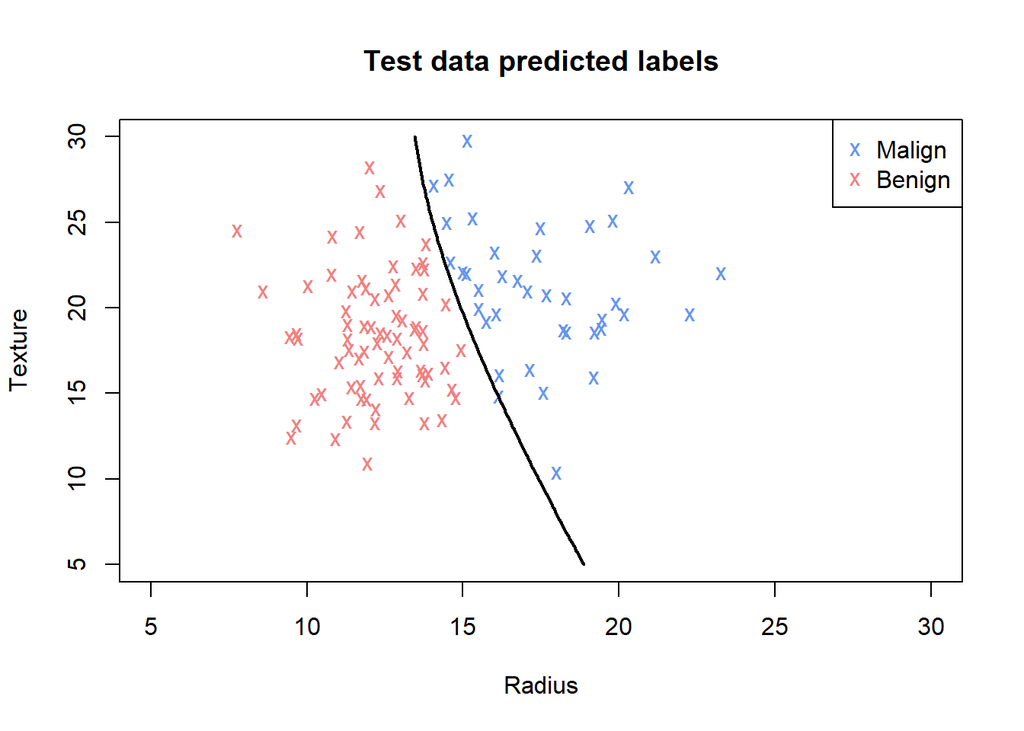

```r
# Create grid over the plotting region (radius and texture)
x1_vals<-seq(5,30,length.out = 100)
x2_vals<-seq(5,30,length.out = 100)

grid <- expand.grid(x1 = x1_vals, x2 = x2_vals)

# Compute decision function values on the grid
grid$decision <- with(grid, a[1,1] * x1^2 + 2 * a[1,2] * x1 * x2 + a[2,2] * x2^2 + b_t[1] * x1 + b_t[2] * x2 + c)
# Reshape into matrix form for contour()
z <- matrix(grid$decision, nrow = length(x1_vals), ncol = length(x2_vals))

# Plot existing points
pred_m_ind <- test$prediction_QDA == "M"
pred_b_ind <- test$prediction_QDA == "B"

plot(test$radius[pred_m_ind], test$texture[pred_m_ind],
     xlab = "Radius", ylab = "Texture",
     col = "cornflowerblue", pch = 'x',
     xlim = c(5, 30), ylim = c(5, 30),
     main = "Test data predicted labels")

points(test$radius[pred_b_ind], test$texture[pred_b_ind],
       col = "lightcoral", pch = 'x')

legend("topright", legend = c("Malign", "Benign"),
       col = c("cornflowerblue", "lightcoral"), pch = c('x', 'x'))

# Add decision boundary contour line
contour(x1_vals, x2_vals, z, levels = 0, add = TRUE, drawlabels = FALSE, lwd = 2, col = "black")
```

#### 💪 Problem 2.3

Compare the quadratic discriminant classifier to the linear discriminant and logistic classifiers from Problem 1. Discuss the results.

**Note**

**Answers:**

In this dataset, QDA doesn’t perform as well as LDA, and interestingly, performs exactly the same as logistic regression model.

QDA is designed to handle complex patterns by allowing each class to have its own covariance matrix, which leads to curved (quadratic) decision boundaries. That flexibility can be useful, but in this case, it may be too much for this data set— the training set is relatively small (fewer than 500 observations in train set), and there are only two features. As a result, QDA likely overfits, picking up noise instead of meaningful patterns.

On the other hand, LDA performs quite well, with an accuracy of about 90%, suggesting that the decision boundary is probably close to linear. If that’s the case, adding complexity with a curved boundary — as QDA does — doesn’t help and may even hurt performance.

#### 💪 Problem 2.4

A doctor contacts you and says she has a patient whose digitised image has the features `radius=13.20` and `texture=19.22`. Use your best classifier from Problem 2.3 to provide the doctor with some advice.

```r
new_patient = as.numeric(data.frame(radius = 13.2, texture = 19.22))
posterior_new_m = -0.5*t(new_patient - mu_m_train)%*%solve(common_cov)%*%(new_patient - mu_m_train) +log(pi_m_train)
posterior_new_b = -0.5*t(new_patient - mu_b_train)%*%solve(common_cov)%*%(new_patient - mu_b_train) +log(pi_b_train)
  if (posterior_new_m >= posterior_new_b){
    predictions_new <- "M"
  } else {
    predictions_new <- "B"}

# Print results in a friendly format
cat("Predicted class:", predictions_new, "\n")
```

```
Predicted class: B
```

**Note**

**Answers:**

The best classifier in 2.3 is the LDA model. Based on the prediction of this model, the patient’s condition should be classified as benign.

## 3. Unsupervised Gaussian mixture models (2 marks)

Both Problems 1 and 2 above are so-called supervised learning methods because the class labels are observed (we know the status of the tumor). In many problems, we do not observe the classes and we might not even know if the classes are interpretable as in the example above (the classes are interpreted as the severity of the tumor). Let us consider two examples to further illustrate what we mean with interpretability.

The first example concerns a dataset that contains measurements of the lengths (in mm) of 1000 insects of a certain species. The data is stored in the file `insects.Rdata`, which can be downloaded from the Canvas page of the course. The following code reads in and visualises the data.

```r
rm(list=ls()) # Remove variables
cat("\014") # Clean workspace
```

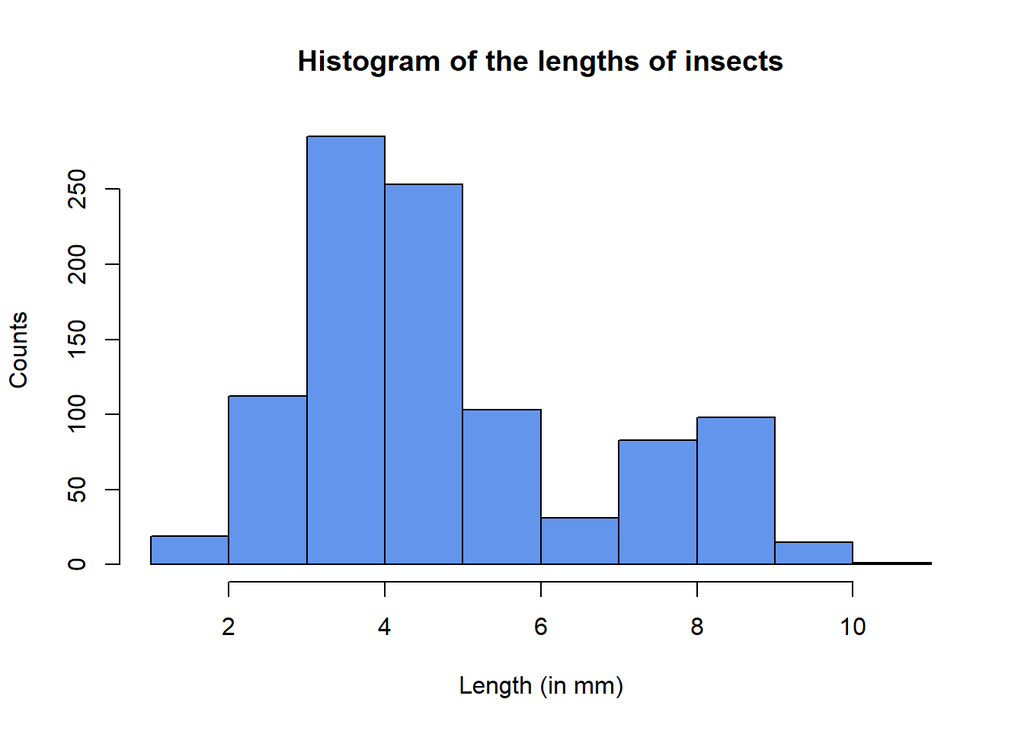

```r
load("C:/Users/26038024/Downloads/insects.RData")
hist(insects$length, xlab = "Length (in mm)", ylab = "Counts", col = "cornflowerblue", main = "Histogram of the lengths of insects")
```

We see that there seems to be two groups of insects, the first group with lengths about $\approx1\text{-}6$mm and the second group with lengths about $\approx7\text{-}11$mm. Note that there are no other variables available in the dataset, but a plausible explanation that the data cluster this way is a second variable — *sex*. This is what we mean with cluster interpretability.

The next example concerns the relationship between the closing price and the trading volume (in log-scale) for the Associated Banc-Corp (ASB) stock that is traded in the New York Stock Exchange (NYSE). The data are on a daily frequency and cover the period 2014-12-26 to 2017-11-10. The data are stored in the file `asb.Rdata`, which can be downloaded from the Canvas page of the course[^2]. The following code reads in and visualises the data.

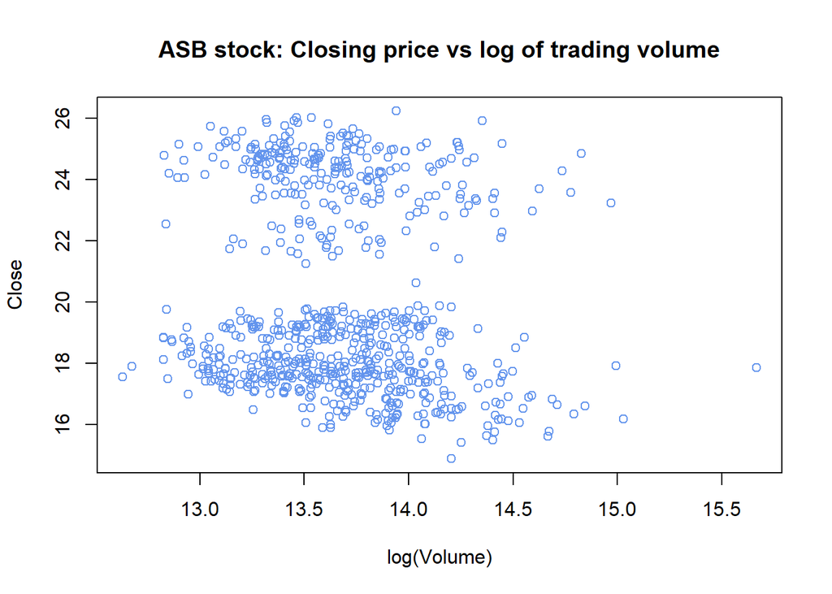

```r
load("C:/Users/26038024/Downloads/asb.RData")
plot(Close ~ log(Volume), data = asb, col = "cornflowerblue", main = "ASB stock: Closing price vs log of trading volume")
```

The data seem to be divided into two clusters. The following code plots a time series plot of the closing price.

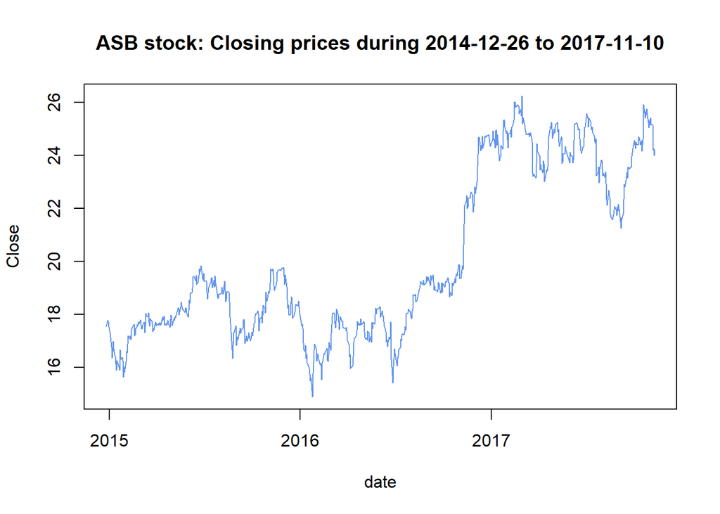

```r
date <- as.Date(asb$Date)
Close <- asb$Close
plot(date, Close, col = "cornflowerblue",type = "l", main = "ASB stock: Closing prices during 2014-12-26 to 2017-11-10")
```

#### 💪 Problem 3.1

Give a possible interpretation of the two clusters.

**Note**

**Answers:**

The data of ASB stocks seems to be divided into 2 clusters: Cluster 1 [closing prices from 15 to 20], and Cluster 2 [closing prices above 20, to 26]. Based on the time series plot, Cluster 1 represents the data from December 2014 to around November 2016, and Cluster 2 represents the data from December 2016 to November 2017.

Further insights of the unsupervised Gaussian mixture model can be gained by understanding the data generating process via simulation. Assume we have only one feature (like the insects example) and two classes. Let

$$x|y=m, \mu_m, \sigma^2_m \sim \mathcal{N}(\mu_m, \sigma^2_m),\,\,m=1,2,$$

with $\mu_1 = -2,\sigma_1=0.5, \mu_2=4, \sigma_2=1.5$. Assume further that $\pi_1=\Pr(y=1) = 0.2$ and $\pi_2= \Pr(y=2) = 0.8$.

#### 💪 Problem 3.2

Derive (analytically) $p(x)$ for the example above.

**Note**

**Answers:**

We have $p(\mathbf{x})=\sum_{m=1}^{2} p(\mathbf{x}, y=m, \mu_m, \sigma^2_m) = \sum_{m=1}^{2} p(\mathbf {x}|y=m, \mu_m, \sigma^2_m) . p(y=m, \mu_m, \sigma^2_m)$

Since we know $\mu_m$ and $\sigma^2_m$ are constant to each class, we can write $p(\mathbf x)$ as:

$p(\mathbf{x}) = \sum_{m=1}^{2} p(\mathbf {x}|y=m, \mu_m, \sigma^2_m) . p(y=m)$ $(1)$

With $x|y=m, \mu_m, \sigma^2_m \sim \mathcal{N}(\mu_m, \sigma^2_m),$ $m=1,2$ , we can write $p(\mathbf x)$ as:

$p(\mathbf x|y=m, \mu_m, \sigma^2_m) = \frac{1}{\sqrt{2\pi \sigma_m^2}} \exp\left( -\frac{(x - \mu_m)^2}{2\sigma_m^2} \right)$ $(2)$

and $p(y=m) = Pr(y=m) = \pi_m$ $(3)$

Plug $(2)$ and $(3)$ into $(1)$, we have:

$p(\mathbf{x}) = \sum_{m=1}^{2} \frac{1}{\sqrt{2\pi \sigma_m^2}} \exp\left( -\frac{(x - \mu_m)^2}{2\sigma_m^2} \right) \times \pi_m$

$\Leftrightarrow p(\mathbf x) = \frac{1}{\sqrt{2\pi \sigma_1^2}} \exp\left( -\frac{(x - \mu_1)^2}{2\sigma_1^2} \right) \times \pi_1 + \frac{1}{\sqrt{2\pi \sigma_2^2}} \exp\left( -\frac{(x - \mu_2)^2}{2\sigma_2^2} \right) \times \pi_2$

$\Leftrightarrow p(\mathbf x) = \frac{1}{\sqrt{2\pi 0.5^2}} \exp\left( -\frac{(x + 2)^2}{2\times 0.5^2} \right) \times 0.2 + \frac{1}{\sqrt{2\pi 1.5^2}} \exp\left( -\frac{(x - 4)^2}{2\times 1.5^2} \right) \times 0.8$

$\Leftrightarrow p(\mathbf x) = \frac{2}{5\sqrt{2\pi}} \exp\left( -\frac{(x + 2)^2}{0.5} \right) + \frac{8}{15\sqrt{2\pi}} \exp\left( -\frac{(x - 4)^2}{4.5} \right)$

The following code simulates $n=1000$ observations from the specified mixture model above. It uses a for-loop for pedagogical reasons. Some explanation of the code follows.

```r
mu1 <- -2
sigma1 <- 0.5
mu2 <- 4
sigma2 <- 1.5
pi1 <- 0.2
pi2 <- 1 - pi1
# Store in vectors:
mu <- c(mu1, mu2)
sigma <- c(sigma1, sigma2)
pis <- c(pi1, pi2)
n <- 1000
y <- rep(NA, n)
x <- rep(NA, n)

for(i in 1:n){
  # Simulate indicator with probability pi2 (1 - component 2, 0 - component 1)
  y[i] <- rbinom(n = 1, size=1, prob = pis[2]) + 1
  x[i] <- rnorm(n = 1, mean = mu[y[i]], sd = sigma[y[i]])
}

# Sanity check: Confirm the marginal class probabilities are pi1 and pi2 (approx)
library(glue)

cat(glue("Estimated class 1 marginal probability: {mean(y == 1)}. True: {pis[1]}.\n",
         "Estimated class 2 marginal probability: {mean(y == 2)}. True: {pis[2]}."))
```

```
Estimated class 1 marginal probability: 0.223. True: 0.2.
Estimated class 2 marginal probability: 0.777. True: 0.8.
```

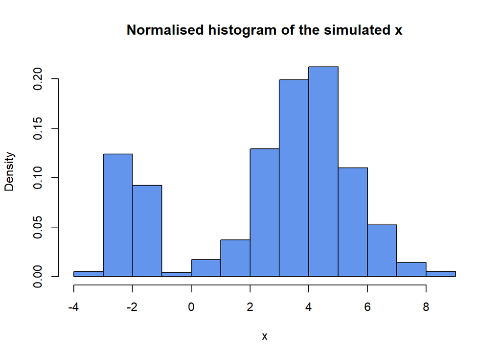

```r
# Normalised histogram
hist(x, xlab = "x", col = "cornflowerblue", main = "Normalised histogram of the simulated x", prob = TRUE)
```

Most of the code above is obvious except that within the for-loop. The function `rbinom()` simulates `n=1` random number from a binomial distribution with `size=1` trials and success probability `prob=pis[2]`. This is just a Bernoulli variable that takes on the value 0 and 1 with, respectively, probabilities $\pi_1$ and $\pi_2$. We add 1 to this to make the outcome $m=1,2$ (instead of $m=0,1$). The next line of code simulates from a normal distribution, where the mean and variance depend on the class membership of the observation (stored in `y[i]`).

Plotting a (normalised) histogram of the simulated data (`x`) is an empirical representation of the marginal density $p(x)$ you derived in Problem 3.2. By comparing them, we can ensure that the simulation above is correct (and that the expression you derived for $p(x)$ is correct!).

#### 💪 Problem 3.3

Plot the $p(x)$ you derived in Problem 3.2 in the same figure as a (normalised) histogram.

**Tip**

Create a fine grid of $x$ values (e.g. `x_grid<-seq(-6,10,length.out=1000)`) and evaluate $p(x)$ on the grid. Make sure to set `prob=TRUE` in the `hist()` function (so the plots are in the same scale). Note that with a few bins it is hard to evaluate the quality of the approximation. Try setting the argument `breaks=30` in the `hist()` function.

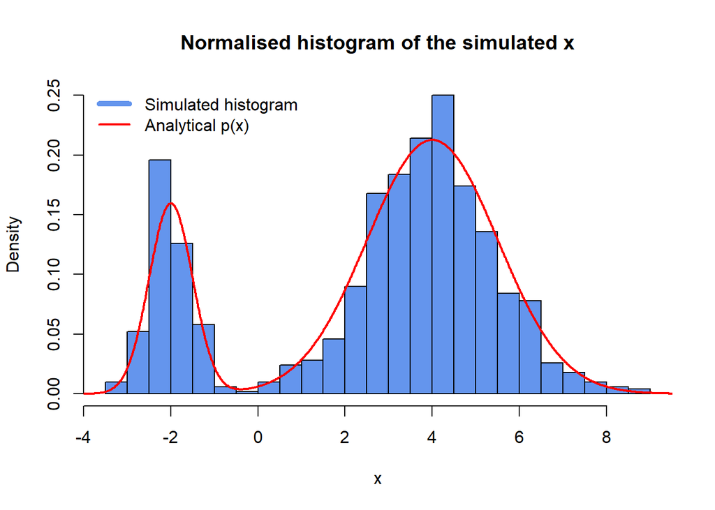

```r
x_grid<-seq(-6,10,length.out=1000)
p_x_grid <- (1 / sqrt(2 * pi * sigma1^2)) * exp(- (x_grid - mu1)^2 / (2 * sigma1^2)) * pi1 +(1 / sqrt(2 * pi * sigma2^2)) * exp(- (x_grid - mu2)^2 / (2 * sigma2^2)) * pi2

hist(x, xlab = "x", col = "cornflowerblue", main = "Normalised histogram of the simulated x", prob = TRUE, breaks = 30)
lines(x_grid, p_x_grid, col = "red", lwd = 2)
legend("topleft",
       legend = c("Simulated histogram", "Analytical p(x)"),
       col = c("cornflowerblue", "red"),
       lwd = c(5, 2), bty = "n")
```

## 4. Unsupervised learning via the EM algorithm (5 marks)

The expectation-maximisation (EM) algorithm is a powerful algorithm to learn the parameters in unsupervised learning models. In addition, the EM algorithm gives us the conditional (on the training data) distribution of the class membership for each observation, which we can use for classification. We will first learn how to implement the EM algorithm for the unsupervised Gaussian mixture model for a single feature $x$ and two classes, which we studied in Problem 3. We stress that the difference compared to Problems 1 and 2 (which also had Gaussian components) is that the labels are not observed in this problem.

The following function implements the EM algorithm. The implementation assumes a single feature and two classes, i.e. $x\in\mathbb{R}$ and $M=2$.

```r
# I modified your code so it can take in any number of classes
EM_GMM_M <- function(x, mu_start, sigma_start, pis_start, n_iter = 100) {
  # Estimates the parameters in an unsupervised Gaussian mixture model with M = 2 classes.
  # Runs the EM algorithm for n_iter iterations. x is assumed univariate.
  # mu_start, sigma_start, pis_start are starting values.
  stopifnot(sum(pis_start) == 1)
  # Quantities to save
  pis_all <-  matrix(NA, nrow = n_iter, ncol = length(pis_start))
  mu_all <- matrix(NA, nrow = n_iter, ncol = length(pis_start))
  sigma_all <- matrix(NA, nrow = n_iter, ncol = length(pis_start))
  Q_all <- rep(NA, n_iter)
  log_like_all <- rep(NA, n_iter)

  # Initialise
  mu <- mu_start
  sigma <- sigma_start
  pis <- pis_start
  n <- length(x)
  W <- matrix(0, nrow = n, ncol = length(pis_start)) # Unnormalised weights for each observation
  log_pdf_class <- matrix(0, nrow = n, ncol = length(pis_start)) # The log-likelihood of the two classes for each obs. To compute Q.
  for(j in 1:n_iter){
    # Start EM steps
    # E-step: Compute the expected log-likelihood Q
    for(m in 1:length(pis_start)){
      # The log-density for each class
      log_pdf_class[, m] <- dnorm(x, mean = mu[m], sd = sigma[m], log = TRUE) + log(pis[m])
      # Unnormalised weights
      W[, m] <- pis[m]*dnorm(x, mean = mu[m], sd = sigma[m])
    }
    w <- W/rowSums(W) # Normalise weights
    n_hat <- colSums(w) # Expected number of obs per class
    Q <- sum(rowSums(w*log_pdf_class)) # Expected log-likelihood

    # M-step: Maximise Q. Closed form analytical solution in Gaussian mixture models
    for(m in 1:length(pis_start)){
      pis[m] <- n_hat[m]/n
      mu[m] <- 1/n_hat[m]*sum(w[, m]*x)
      sigma[m] <- sqrt(1/n_hat[m]*sum(w[, m]*(x - mu[m])^2))
    }
    # End EM steps. Save estimates, Q, and log-likelihood
    pis_all[j, ] <- pis
    mu_all[j, ] <- mu
    sigma_all[j, ] <- sigma
    Q_all[j] <- Q
    # Compute log-likelihood at current parameter values
    for(m in 1:length(pis_start)){
      # Unnormalised weights
      W[, m] <- pis[m]*dnorm(x, mean = mu[m], sd = sigma[m])
    }
    log_like_all[j] <-  sum(log(rowSums(W)))
  } # End EM iterations
  # Return everything as a list
  return(list(pi_hat = pis, mu_hat = mu, sigma_hat = sigma,
              weights = W/rowSums(W), pis_all = pis_all,
              mu_all = mu_all, sigma_all = sigma_all, Q_all = Q_all,
              log_like_all = log_like_all))
}
```

The log-likelihood is guaranteed to not decrease at any iteration, which makes the variable `log_like_all` above useful for debugging. The following code uses the function above to estimate the parameters using our simulated data from Problem 3, performs some convergence checks, and plots the class posterior probability distribution for an observation.

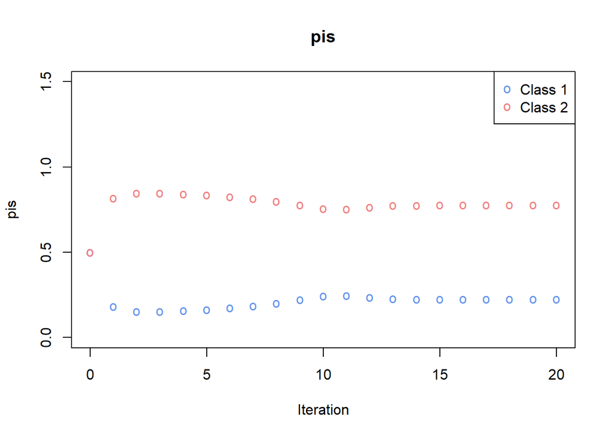

```r
# Initial values
pis_start <- c(0.5, 0.5)
mu_start <- c(1, 4)
sigma_start <- c(1, 3)
n_iter <- 20
EM_result <- EM_GMM_M(x, mu_start, sigma_start, pis_start, n_iter = n_iter)

# Visualise convergence for each parameters (adding starting value)
matplot(0:n_iter, rbind(pis_start, EM_result$pis_all), main = 'pis', pch = c("o", "o"), col = c("cornflowerblue", "lightcoral"), xlab = "Iteration", ylab = "pis", ylim = c(0, 1.5))
legend("topright", legend = c("Class 1", "Class 2"), col = c("cornflowerblue", "lightcoral"), pch = c("o", "o"))
```

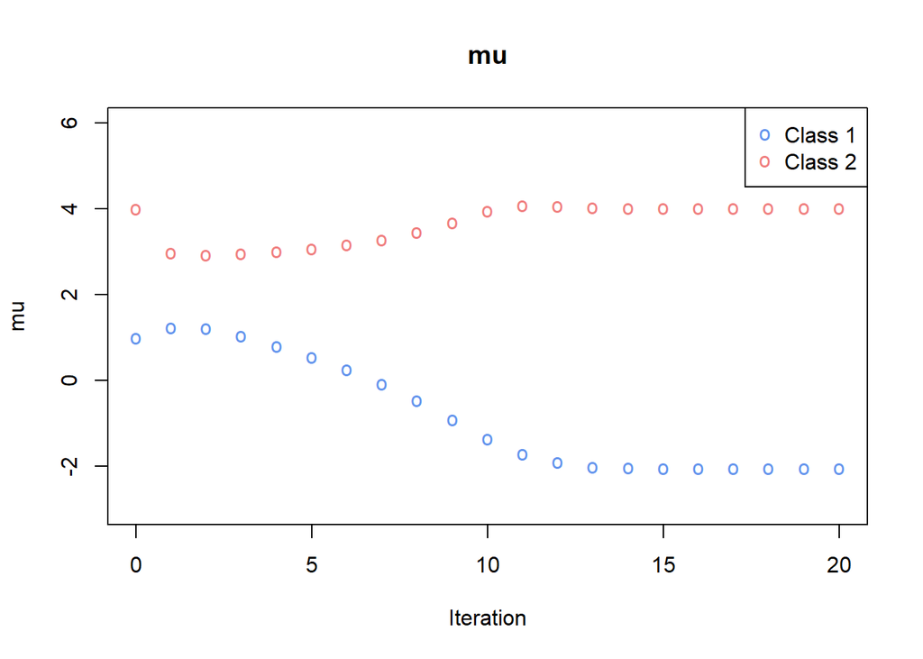

```r
matplot(0:n_iter, rbind(mu_start, EM_result$mu_all), main = 'mu', pch = c("o", "o"), col = c("cornflowerblue", "lightcoral"), xlab = "Iteration", ylab = "mu", ylim = c(-3, 6))
legend("topright", legend = c("Class 1", "Class 2"), col = c("cornflowerblue", "lightcoral"), pch = c("o", "o"))
```

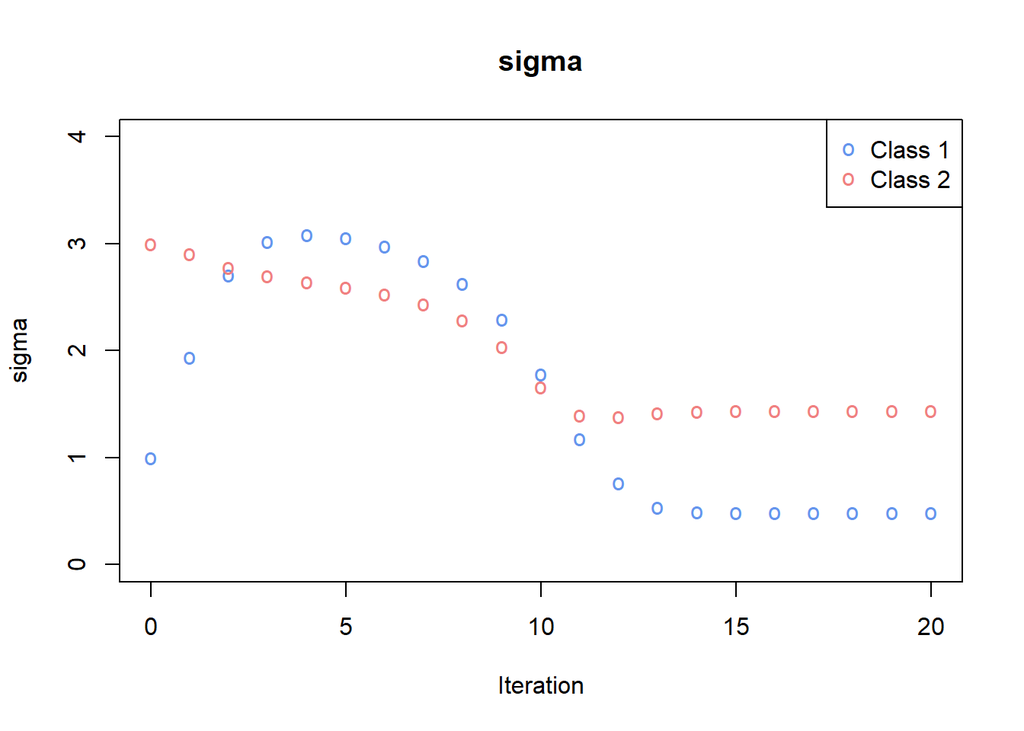

```r
matplot(0:n_iter, rbind(sigma_start, EM_result$sigma_all), main = 'sigma', pch = c("o", "o"), col = c("cornflowerblue", "lightcoral"), xlab = "Iteration", ylab = "sigma", ylim = c(0, 4))
legend("topright", legend = c("Class 1", "Class 2"), col = c("cornflowerblue", "lightcoral"), pch = c("o", "o"))
```

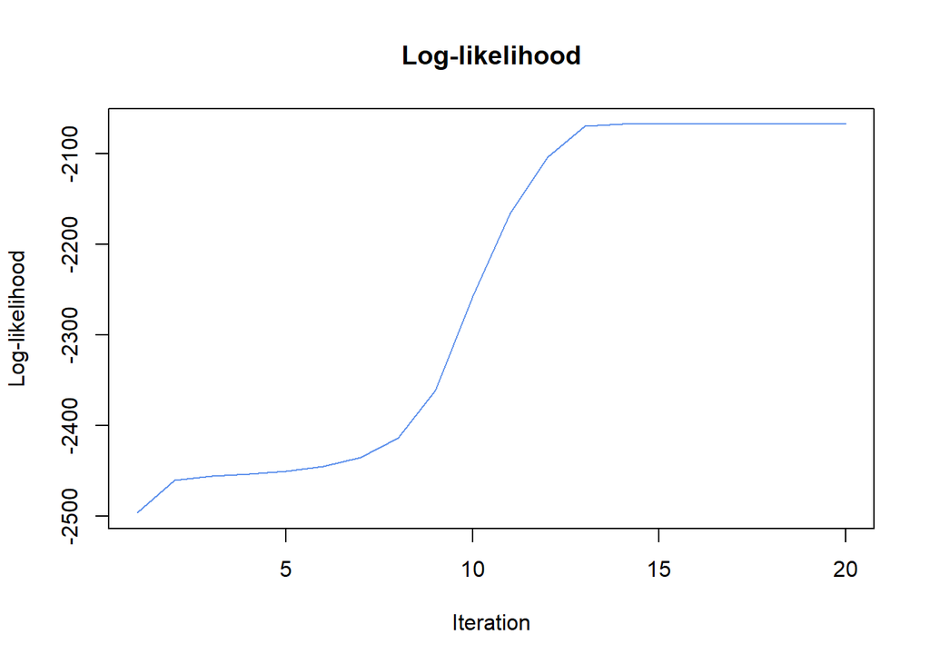

```r
par(mfrow = c(1, 1))
# Inspect convergence
plot(EM_result$log_like_all, main = 'Log-likelihood', type = "l", col = "cornflowerblue", xlab = "Iteration", ylab = "Log-likelihood")
```

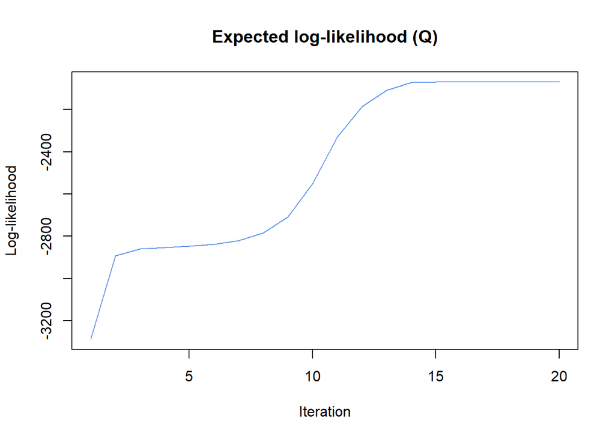

```r
plot(EM_result$Q_all, main = 'Expected log-likelihood (Q)', type = "l", col = "cornflowerblue", xlab = "Iteration", ylab = "Log-likelihood")
```

```r
print("True parameters (pi, mu, and sigma)")
```

```
[1] "True parameters (pi, mu, and sigma)"
```

```r
print(pis)
```

```
[1] 0.2 0.8
```

```r
print(mu)
```

```
[1] -2  4
```

```r
print(sigma)
```

```
[1] 0.5 1.5
```

```r
print("Estimated parameters (pi, mu, and sigma)")
```

```
[1] "Estimated parameters (pi, mu, and sigma)"
```

```r
print(EM_result$pi_hat)
```

```
[1] 0.2235894 0.7764106
```

```r
print(EM_result$mu_hat)
```

```
[1] -2.046600  4.018808
```

```r
print(EM_result$sigma_hat)
```

```
[1] 0.4857986 1.4369935
```

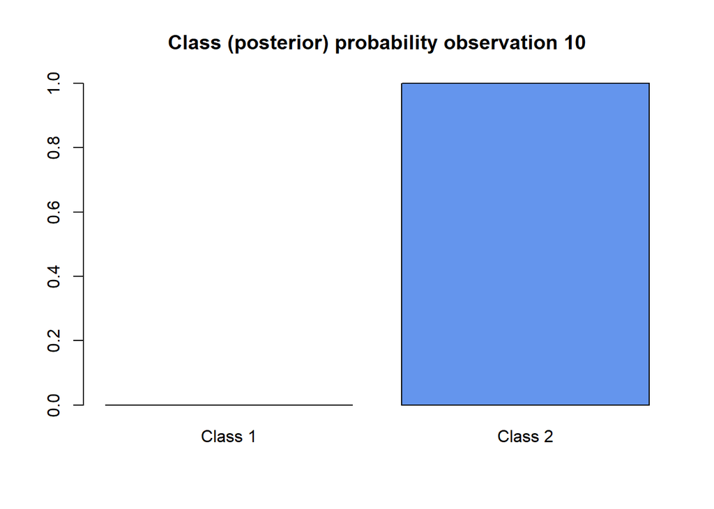

```r
# Inspect the classification probabilities of observation 10
ind <- 10
barplot(names.arg = c("Class 1", "Class 2"), EM_result$weights[ind, ], col = "cornflowerblue", ylim = c(0, 1), main = paste("Class (posterior) probability observation ", ind, sep = ""))
```

#### 💪 Problem 4.1

Explain the label-switching problem when estimating unsupervised Gaussian mixture models. Do you observe label-switching above?

**Note**

**Answers:**

When estimating unsupervised Gaussian mixture models, we are essentially classifying data into labels/categories by estimating the posterior distribution of the models’ parameters when knowing the unlabeled observations.

As the labels are not intrinsically meaningful to the posterior distribution, the posterior distribution is invariant under permutations of the component labels. In other words, if we switch “Label 1” and “Label 2,” the model and the likelihood stay the same.

The problem with label switching is that because any labels permutation makes no different to the model, tracking parameters doesn’t make much sense, as the iterations keep assigning data to different labels and mixes models together.

The label switching problem can be detected by plotting estimated parameters. If the problem exist, the tracking plot will switch between components, or appears multimodal (with multiple peaks) representing multiple models estimated under 1 label.

From the plots above, we observe no color or pattern swap between lines tracking $\mu, \pi, \sigma,$ so we can confidently conclude that there is no label switching problem.

The next problem uses the EM algorithm to estimate an unsupervised Gaussian mixture model for the insects data. In particular, the model will be used to classify three insects: observations 6, 244, and 421 in `insects.Rdata`. The following code plots a (normalised) histogram of the data and highlights the feature values of these three observations.

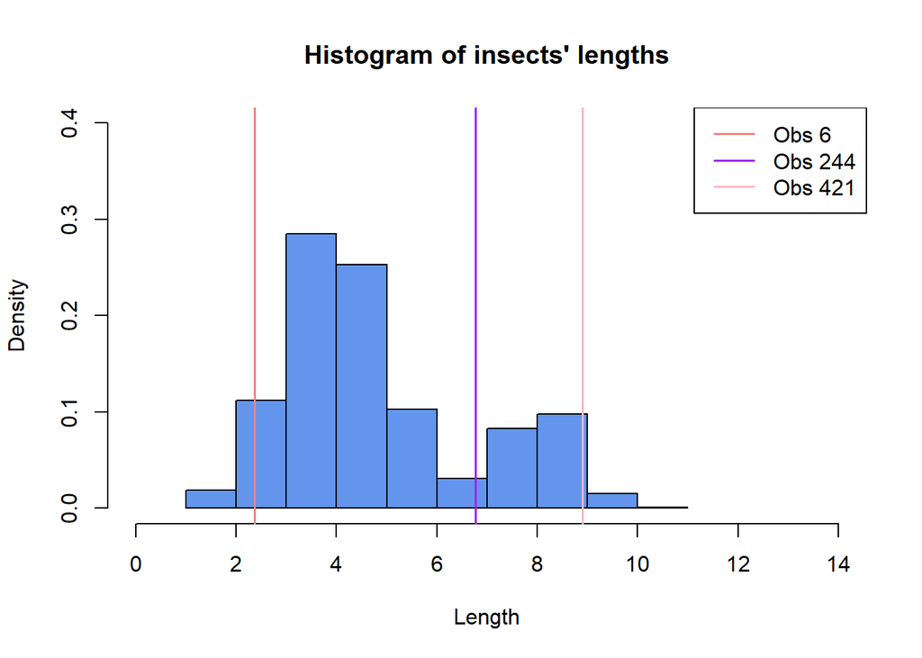

```r
hist(insects$length, col = "cornflowerblue", main = "Histogram of insects' lengths", prob = TRUE, xlab = "Length", ylim = c(0, 0.4), xlim = c(0, 14))
abline(v = insects[6, ], lwd = 1.5, col = "lightcoral")
abline(v = insects[244, ], lwd = 1.5, col = "purple")
abline(v = insects[421, ], lwd = 1.5, col = "lightpink")
legend("topright", legend = c("Obs 6", "Obs 244", "Obs 421"), col = c("lightcoral", "purple", "lightpink"), lwd = c(1.5, 1.5, 1.5))
```

#### 💪 Problem 4.2

Use the `EM_GMM_M2()` function to estimate an unsupervised Gaussian mixture model for the insect data in Problem 3. Analyse the convergence. Compare the parameter estimates to those obtained by the function `normalmixEM()` in the `mixtools` package.

**Tip**

The EM algorithm is sensitive to starting values. Try a few different starting values and pick the solution that gives you the highest log-likelihood value. You might have to increase the number of iterations if you have not achieved convergence yet. Finally, recall that the log-likelihood is guaranteed to not decrease at each iteration.

```r
pis_start <- c(0.5, 0.5)
mu_start <- c(10, 5)
sigma_start <- c(0.1, 0.2)
n_iter <- 50
x_insects <- insects$length
EM_result <- EM_GMM_M(x_insects, mu_start, sigma_start, pis_start, n_iter = n_iter)
```

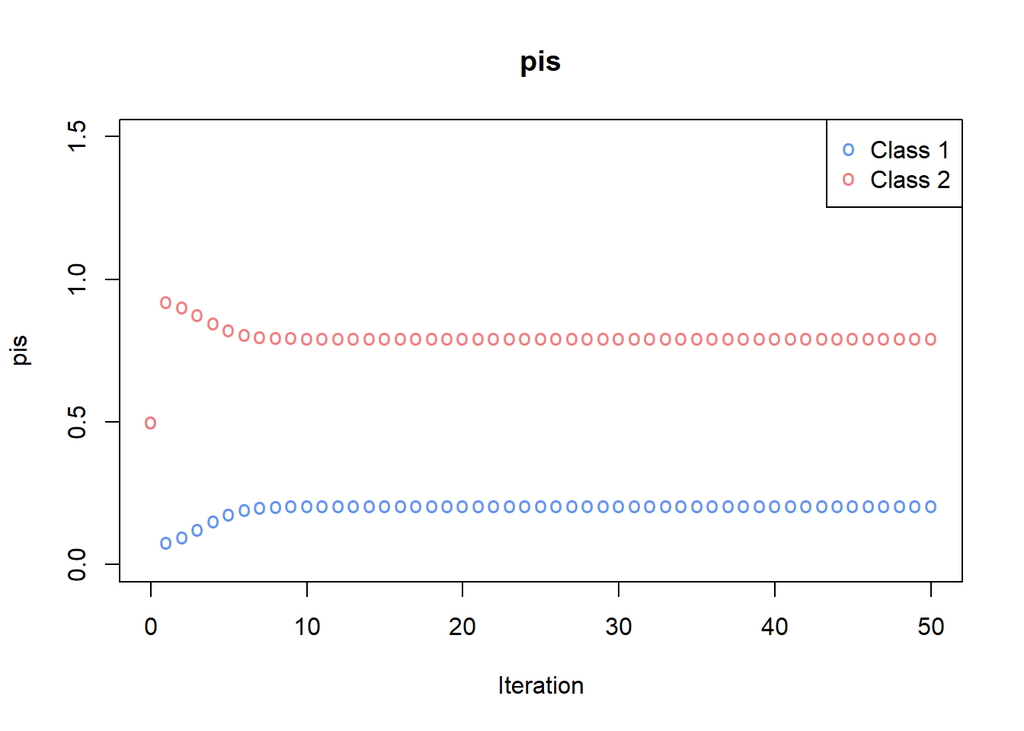

```r
# Visualise convergence for each parameters (adding starting value)
matplot(0:n_iter, rbind(pis_start, EM_result$pis_all), main = 'pis', pch = c("o", "o"), col = c("cornflowerblue", "lightcoral"), xlab = "Iteration", ylab = "pis", ylim = c(0, 1.5))
legend("topright", legend = c("Class 1", "Class 2"), col = c("cornflowerblue", "lightcoral"), pch = c("o", "o"))
```

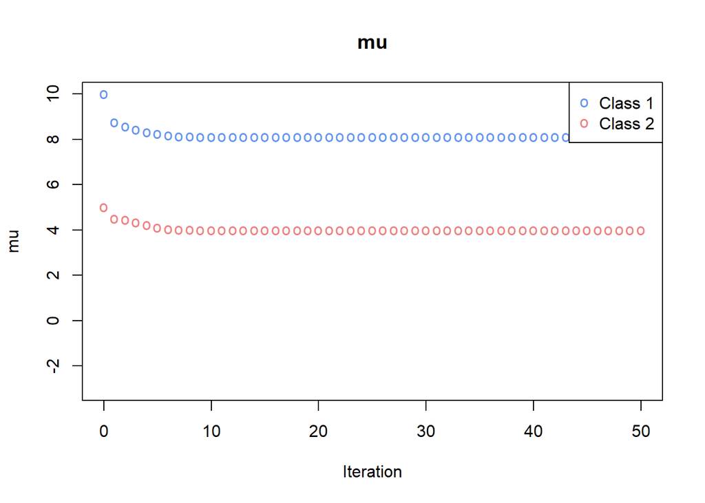

```r
matplot(0:n_iter, rbind(mu_start, EM_result$mu_all), main = 'mu', pch = c("o", "o"), col = c("cornflowerblue", "lightcoral"), xlab = "Iteration", ylab = "mu", ylim = c(-3, 10))
legend("topright", legend = c("Class 1", "Class 2"), col = c("cornflowerblue", "lightcoral"), pch = c("o", "o"))
```

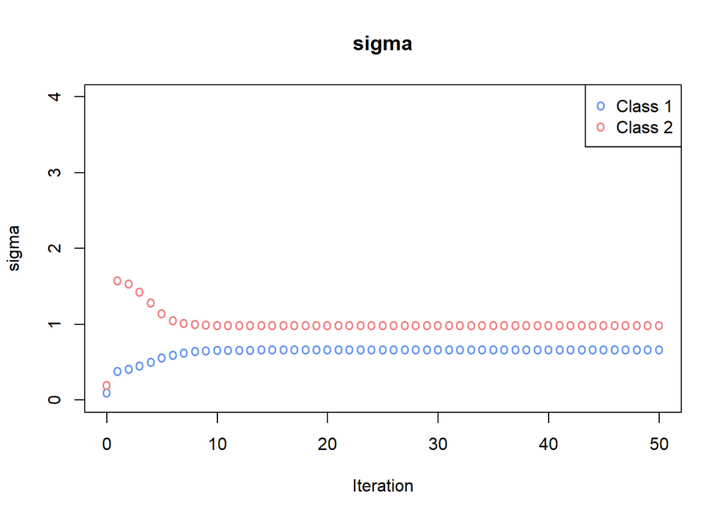

```r
matplot(0:n_iter, rbind(sigma_start, EM_result$sigma_all), main = 'sigma', pch = c("o", "o"), col = c("cornflowerblue", "lightcoral"), xlab = "Iteration", ylab = "sigma", ylim = c(0, 4))
legend("topright", legend = c("Class 1", "Class 2"), col = c("cornflowerblue", "lightcoral"), pch = c("o", "o"))
```

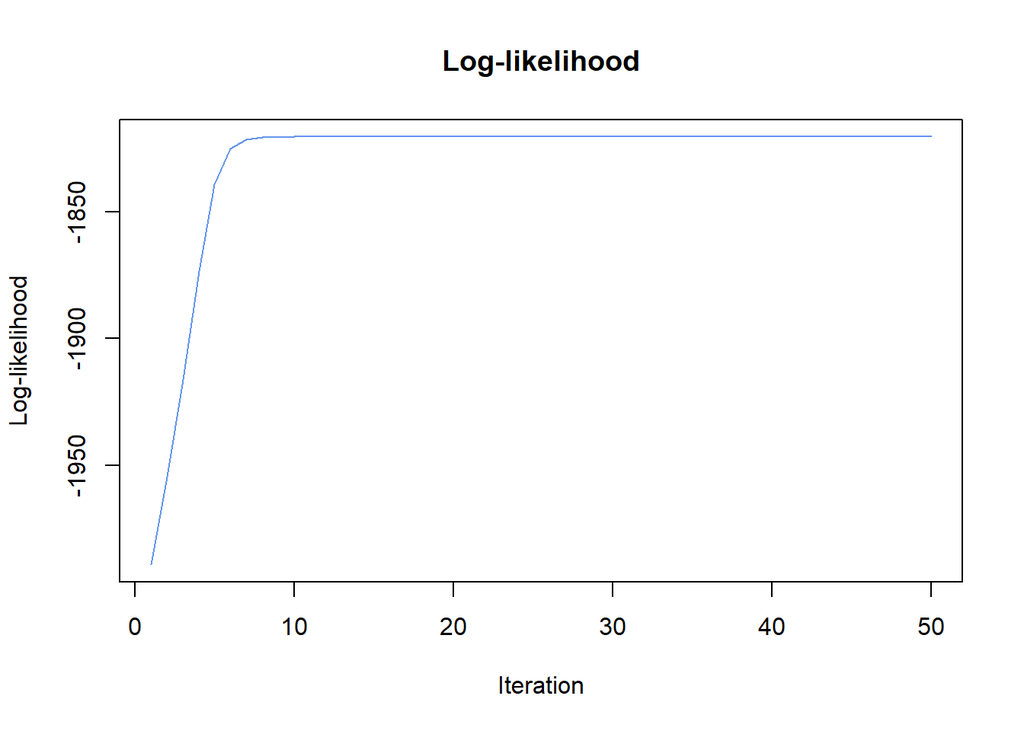

```r
par(mfrow = c(1, 1))
# Inspect convergence
plot(EM_result$log_like_all, main = 'Log-likelihood', type = "l", col = "cornflowerblue", xlab = "Iteration", ylab = "Log-likelihood")
```

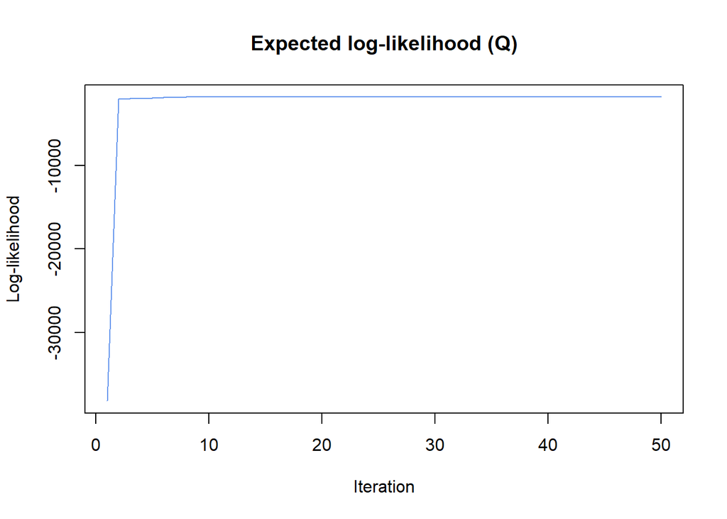

```r
plot(EM_result$Q_all, main = 'Expected log-likelihood (Q)', type = "l", col = "cornflowerblue", xlab = "Iteration", ylab = "Log-likelihood")
```

```r
print("Estimated parameters (pi, mu, and sigma)")
```

```
[1] "Estimated parameters (pi, mu, and sigma)"
```

```r
print(EM_result$pi_hat)
```

```
[1] 0.2064433 0.7935567
```

```r
print(EM_result$mu_hat)
```

```
[1] 8.103937 3.994985
```

```r
print(EM_result$sigma_hat)
```

```
[1] 0.6674929 0.9905863
```

**Note**

**Answers:**

Over the course of 50 iterations, all three sets of parameters — the means, standard deviations, and mixing proportions — as well as the log-likelihood and expected log-likelihood (Q), show smooth and stable convergence.

```r
set.seed(0)
# Run with 2 components
mix_result <- normalmixEM(x_insects, k = 2, maxit = 5000)
```

```
number of iterations= 28
```

```r
# Print results
summary(mix_result)
```

```
summary of normalmixEM object:
         comp 1   comp 2
lambda 0.793556 0.206444
mu     3.994984 8.103935
sigma  0.990586 0.667494
loglik at estimate:  -1820.534
```

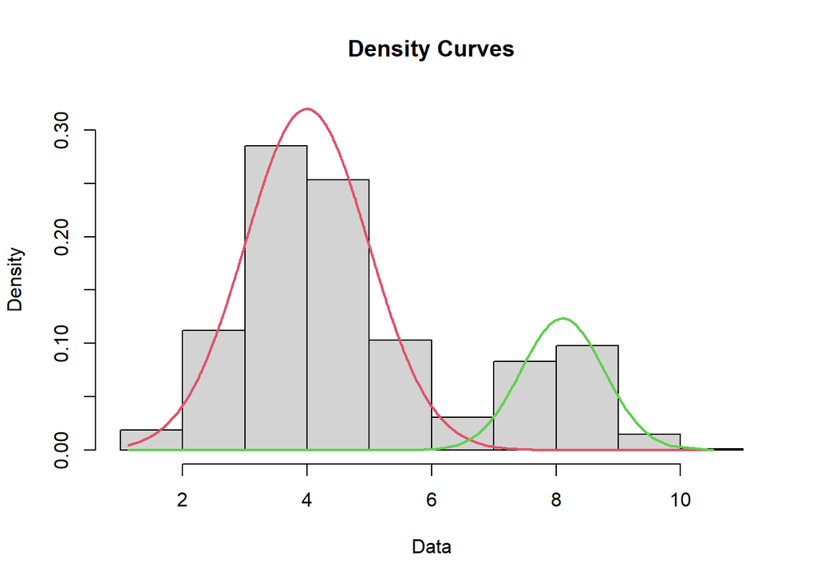

```r
plot(mix_result, which = 2)
```

**Note**

**Answers:**

The results from the `normalmixEM()` function and custom `EM_GMM_M2()` implementation are closely similar — in fact, nearly identical. This suggests that the custom EM algorithm has been correctly implemented and performs just as well as the established method in the **`mixtools`** package.

#### 💪 Problem 4.3

Plot the class posterior probabilities for insects 6, 244, and 421 with the model estimated in Problem 4.2. Are the results as expected? Explain.

**Tip**

The function `EM_GMM_M2()` returns an $n\times2$ matrix `weights`, which contains the class posterior probabilities evaluated at the parameter estimates from the EM algorithm.

```r
print(list(insects$length[c(6,244,421)]))
```

```
[[1]]
[1] 2.373327 6.771978 8.903676
```

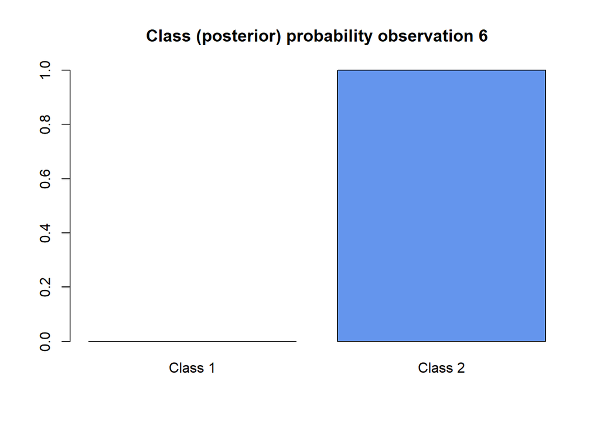

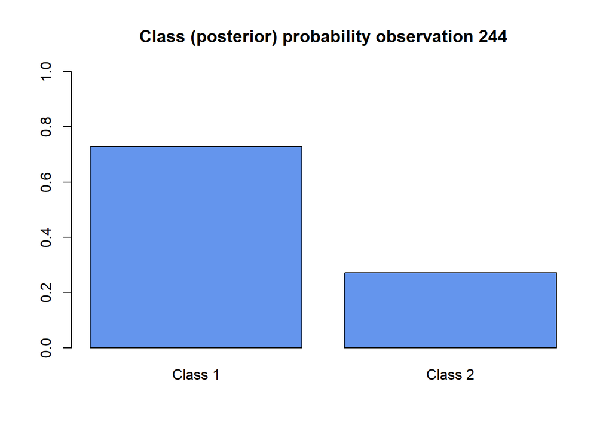

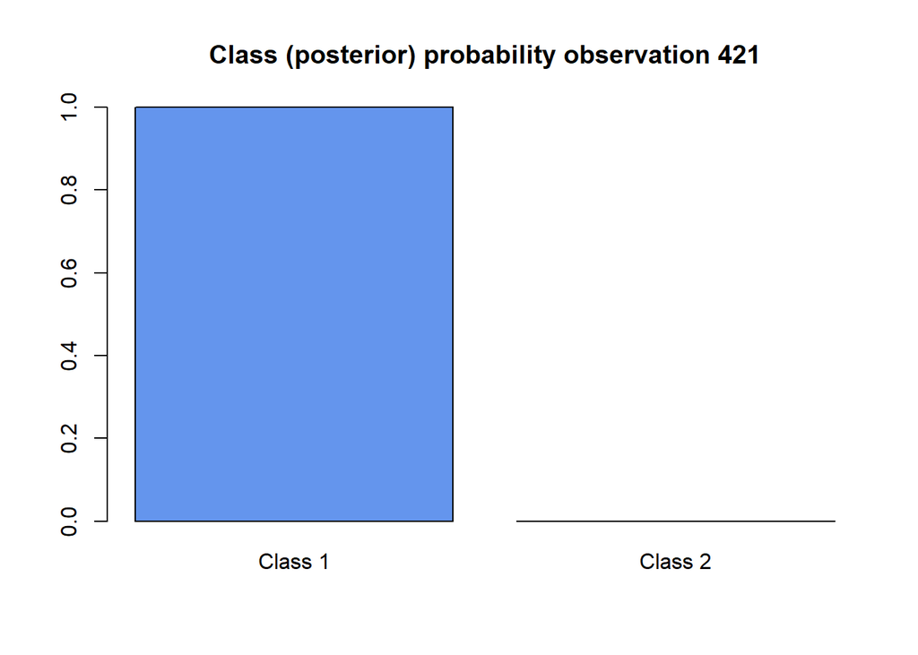

```r
# Inspect the classification probabilities of observation 10
inds <- c(6, 244, 421)

for (ind in inds) {
  barplot(
    EM_result$weights[ind, ],
    col = "cornflowerblue",
    ylim = c(0, 1),
    main = paste("Class (posterior) probability observation ", ind, sep = ""),
    names.arg = paste("Class", 1:ncol(EM_result$weights))
  )
}
```

**Note**

**Answers:**

The model assigned observation 6 to Class 2, while observations 244 and 421 were classified into Class 1. This classification appears reasonable when considering the actual lengths of these observations.

Observations 244 and 421 have similar, relatively large lengths, indicating they likely belong to the same underlying distribution. In contrast, observation 6 has a noticeably smaller length, making it distinct from the other two. The model correctly captured this difference, assigning it to a different class — which aligns well with the natural groupings in the data.

#### 💪 Problem 4.4

Write a function that implements the EM algorithm for the unsupervised Gaussian mixture model with any number of components $M$, i.e. not limited to $M=2$ as the `EM_GMM_M2()` function. You can still assume that $x$ is univariate. Use your function to estimate two models for the dataset `fish.Rdata` with, respectively, $M=3$ and $M=4$ classes. The dataset can be downloaded from the Canvas page of the course. The dataset contains the lengths of 523 fishes.

**Tip**

Choose suitable starting values for the means by considering a histogram with 30 breaks of the data. Make sure you run enough iterations by monitoring the convergence via the log-likelihood and the expected log-likelihood*.*

```r
# I have already modified the EM algorithm so it can take in any number of components M, and used that for lecturer's instruction code, as well as solving problem 4.2
load("C:/Users/26038024/Downloads/fish.RData")
x_fish = fish$length
```

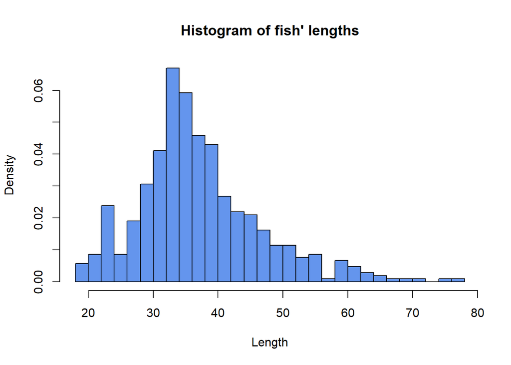

```r
hist(x_fish, col = "cornflowerblue", main = "Histogram of fish' lengths", prob = TRUE, xlab = "Length", breaks = 30)
```

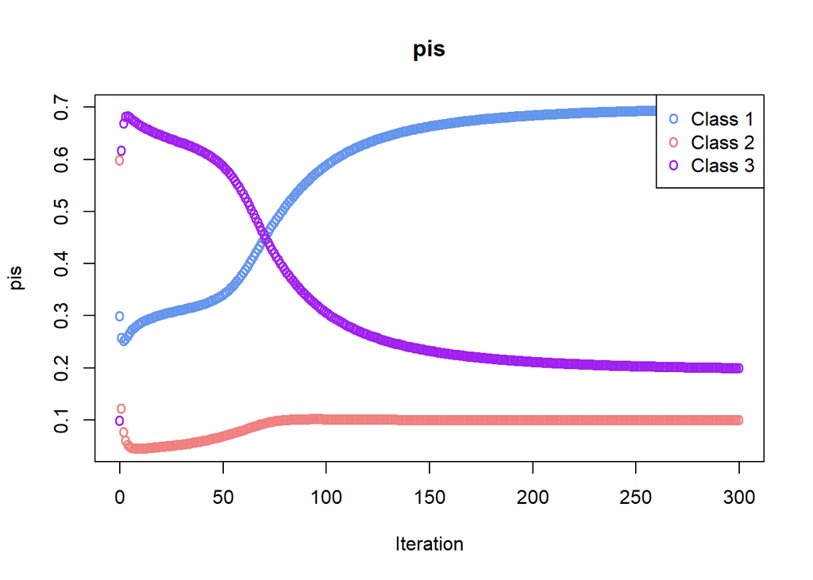

```r
mu_start = c(30,30,30)
pis_start = c(0.3,0.6,0.1)
sigma_start = c(2,1,20)
n_iter = 300
EM_result_3 = EM_GMM_M(x_fish, mu_start, sigma_start, pis_start, n_iter)

matplot(0:n_iter, rbind(pis_start, EM_result_3$pis_all), main = 'pis', pch = c("o", "o",'o'), col = c("cornflowerblue", "lightcoral", 'purple'), xlab = "Iteration", ylab = "pis")
legend("topright", legend = c("Class 1", "Class 2", 'Class 3'), col = c("cornflowerblue", "lightcoral", 'purple'), pch = c("o", "o", 'o'))
```

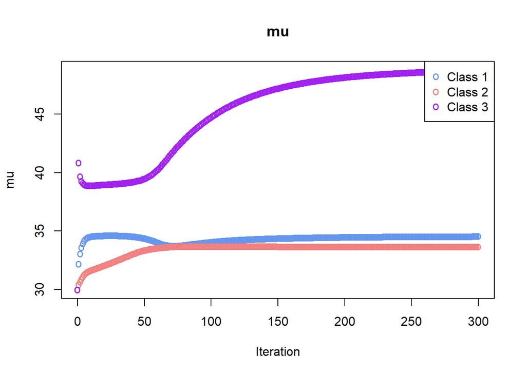

```r
matplot(0:n_iter, rbind(mu_start, EM_result_3$mu_all), main = 'mu', pch = c("o", "o", 'o'), col = c("cornflowerblue", "lightcoral", 'purple'), xlab = "Iteration", ylab = "mu")
legend("topright", legend = c("Class 1", "Class 2", 'Class 3'), col = c("cornflowerblue", "lightcoral", 'purple'), pch = c("o", "o",'o'))
```

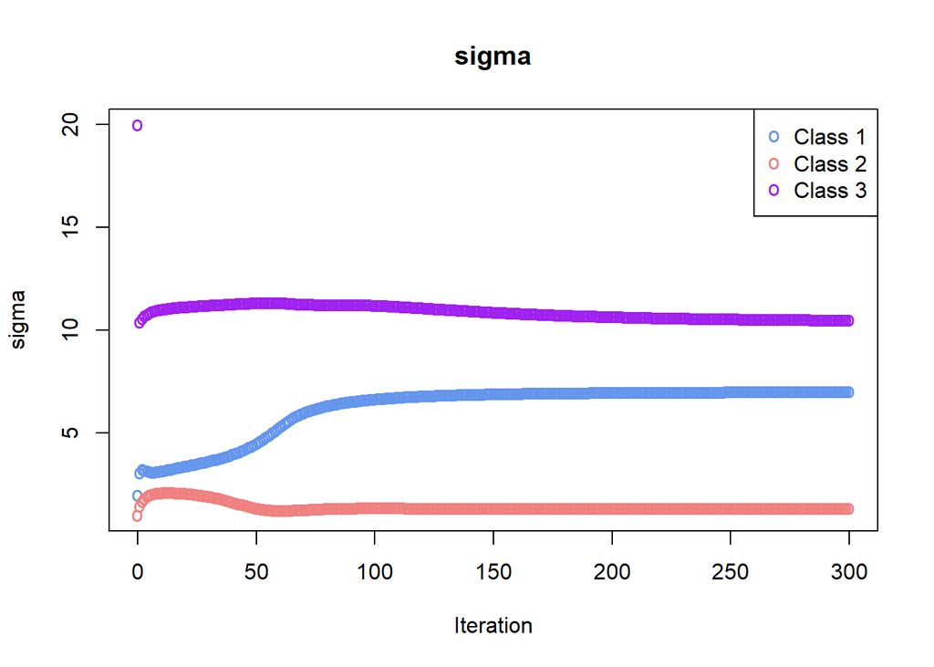

```r
matplot(0:n_iter, rbind(sigma_start, EM_result_3$sigma_all), main = 'sigma', pch = c("o", "o", 'o'), col = c("cornflowerblue", "lightcoral", 'purple'), xlab = "Iteration", ylab = "sigma")
legend("topright", legend = c("Class 1", "Class 2", 'Class 3'), col = c("cornflowerblue", "lightcoral", 'purple'), pch = c("o", "o", 'o'))
```

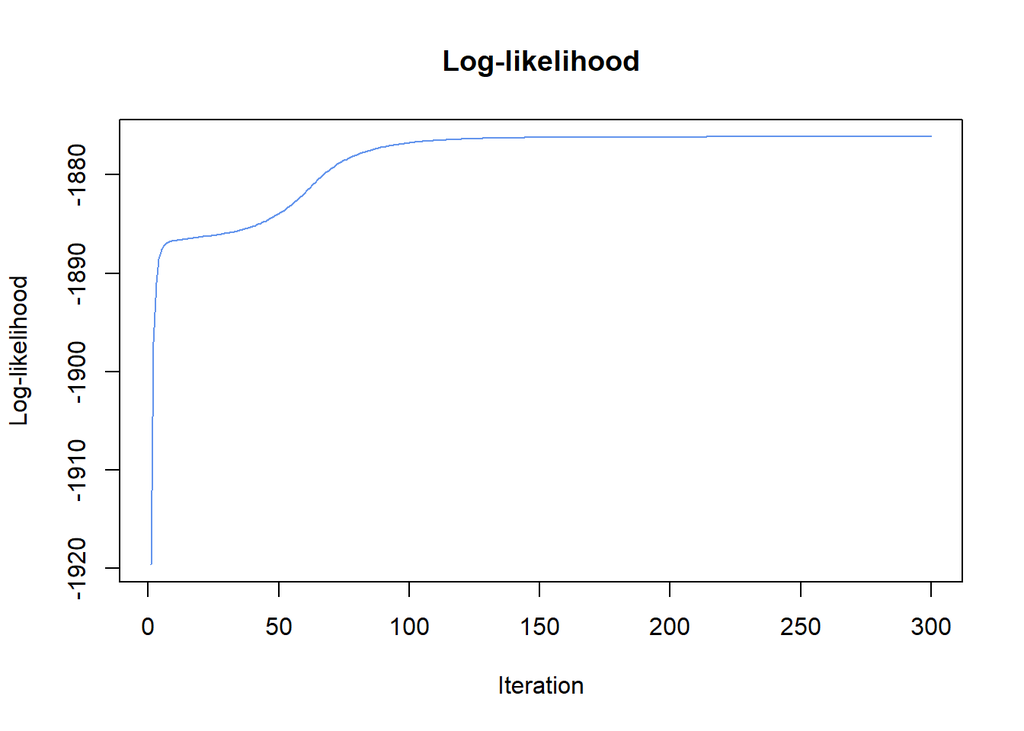

```r
par(mfrow = c(1, 1))
# Inspect convergence
plot(EM_result_3$log_like_all, main = 'Log-likelihood', type = "l", col = "cornflowerblue", xlab = "Iteration", ylab = "Log-likelihood")
```

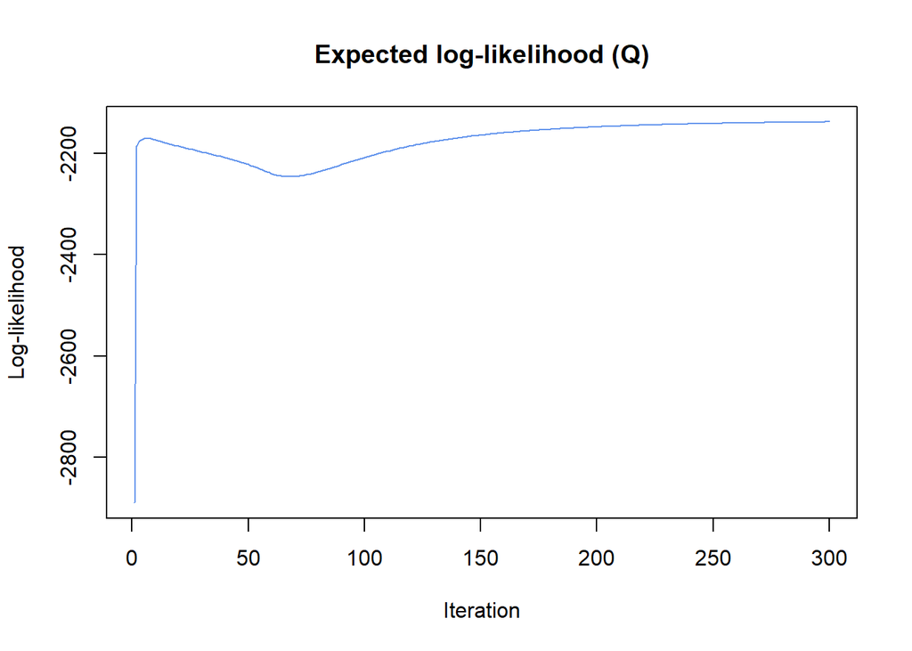

```r
plot(EM_result_3$Q_all, main = 'Expected log-likelihood (Q)', type = "l", col = "cornflowerblue", xlab = "Iteration", ylab = "Log-likelihood")
```

```r
print("Estimated parameters (pi, mu, and sigma)")
```

```
[1] "Estimated parameters (pi, mu, and sigma)"
```

```r
print(EM_result_3$pi_hat)
```

```
[1] 0.6977658 0.1013539 0.2008803
```

```r
print(EM_result_3$mu_hat)
```

```
[1] 34.56285 33.68315 48.74764
```

```r
print(EM_result_3$sigma_hat)
```

```
[1]  7.022167  1.347444 10.513335
```

```r
mu_start = c(30,30,30,30)
pis_start = c(0.3,0.5,0.1, 0.1)
sigma_start = c(2,1,20, 30)
n_iter = 300
EM_result_4 = EM_GMM_M(x_fish, mu_start, sigma_start, pis_start, n_iter)
```

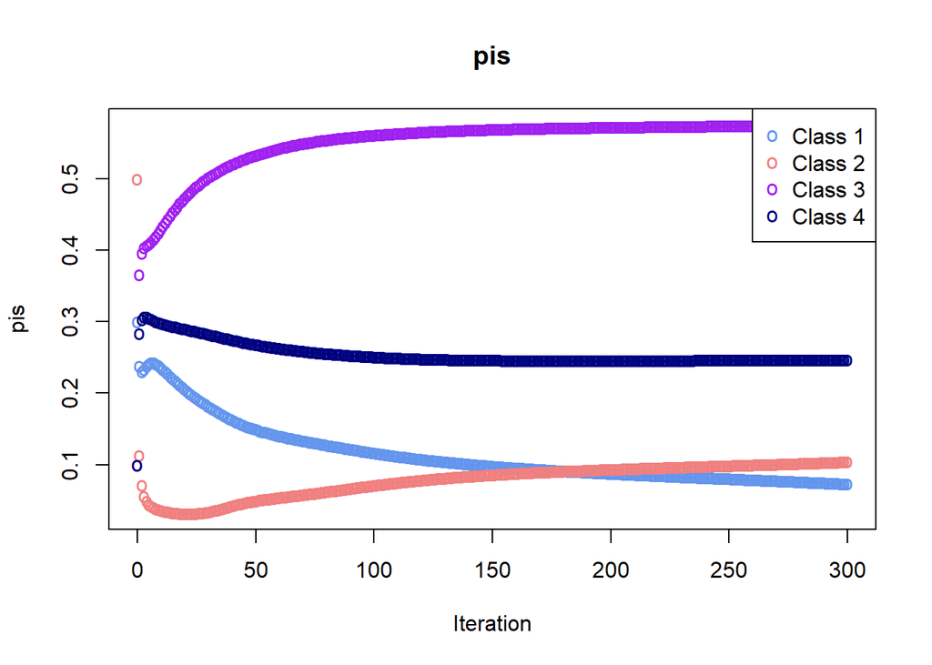

```r
matplot(0:n_iter, rbind(pis_start, EM_result_4$pis_all), main = 'pis', pch = c("o", "o",'o'), col = c("cornflowerblue", "lightcoral", 'purple', 'navy'), xlab = "Iteration", ylab = "pis")
legend("topright", legend = c("Class 1", "Class 2", 'Class 3', 'Class 4'), col = c("cornflowerblue", "lightcoral", 'purple', 'navy'), pch = c("o", "o", 'o', 'o'))
```